# Codebook Pilot 2

Here, we’re just setting a few options.

```r
knitr::opts_chunk$set(
  warning = FALSE, # show warnings during codebook generation
  message = FALSE, # show messages during codebook generation
  error = FALSE, # do not interrupt codebook generation in case of errors,
                # usually better for debugging
  echo = TRUE  # show R code
)
ggplot2::theme_set(ggplot2::theme_bw())
```

```r
library(codebook)
library(here)
library(dplyr)


codebook_data <- rio::import(here("data/pilot2_data.sav"))%>%
  dplyr::select(id:donation) %>%
  dplyr::mutate(resourcePerson_va = rowMeans(across(matches("resourcePerson_va")),
                                             na.rm = TRUE),
                resourcePerson_eos = rowMeans(across(matches("resourcePerson_eos")),
                                             na.rm = TRUE),
                # resourceInfra = rowMeans(across(matches("resourceInfra")),
                #                          na.rm = TRUE),
                implicates_self = rowMeans(across(matches("implicates_self")),
                                           na.rm = TRUE),
                challenge = rowMeans(across(matches("challenge")),
                                     na.rm = TRUE),
                threat = rowMeans(across(matches("threat")),
                                  na.rm = TRUE),
                engage_cognitive = rowMeans(across(matches("engage_cognitive")),
                                            na.rm = TRUE))


reverse_coded_items <- c("resourcePerson_eos4",
                         "engage_cognitive01",
                         "engage_cognitive04",
                         "engage_cognitive06",
                         "engage_cognitive08",
                         "engage_cognitive09")

codebook_data <- codebook_data %>%
  rename_with(.fn = add_R, .cols = reverse_coded_items) %>%
  mutate(across(dplyr::matches("\\dR$"), reverse_labelled_values))


codebook_data$resourceInfra <- codebook_data %>%
  dplyr::select(contains("resourceInfra")) %>%
  aggregate_and_document_scale()

codebook_data <- detect_scales(codebook_data)
```

Create codebook

```r
codebook(codebook_data)
```

```
## Some items ( engage_cognitive04R ) were negatively correlated with the first principal component and
## probably should be reversed.
## To do this, run the function again with the 'check.keys=TRUE' option
```

### Metadata

#### Description

**Dataset name**: codebook_data

The dataset has N=28 rows and 66 columns. 14 rows have no missing values on any column.

**Metadata for search engines**

- **Date published**: 2025-09-16

| x |
| --- |
| id |
| submitdate |
| lastpage |
| startlanguage |
| seed |
| datenschutz |
| consentInfo_yes |
| introScenario |
| vignetteVersionA |
| resourcePerson_va4 |
| resourcePerson_eos6 |
| resourcePerson_eos1 |
| resourcePerson_eos2 |
| resourcePerson_va3 |
| resourcePerson_eos3 |
| resourcePerson_eos5 |
| resourcePerson_va1 |
| resourcePerson_va2 |
| resourcePerson_eos4R |
| resourceInfra_peer1 |
| resourceInfra_peer2 |
| resourceInfra_formal1 |
| resourceInfra_formal2 |
| resourceInfra_train1 |
| resourceInfra_train2 |
| resourceInfra_incent1 |
| resourceInfra_incent2 |
| experience |
| introText |
| headerExpectations |
| implicates_self1 |
| implicates_self2 |
| implicates_self3 |
| implicates_self4 |
| challenge_1 |
| challenge_2 |
| challenge_3 |
| challenge_4 |
| threat_1 |
| threat_2 |
| threat_3 |
| infotext |
| engage_cognitive01R |
| engage_cognitive02 |
| engage_cognitive03 |
| engage_cognitive04R |
| engage_cognitive05 |
| engage_cognitive06R |
| engage_cognitive07 |
| engage_cognitive08R |
| engage_cognitive09R |
| engage_cognitive10 |
| gender |
| age |
| country |
| careerStage |
| engageBehavioral |
| downloadText |
| donation |
| resourcePerson_va |
| resourcePerson_eos |
| implicates_self |
| challenge |
| threat |
| engage_cognitive |
| resourceInfra |

## Variables

### id

Response ID

#### Distribution

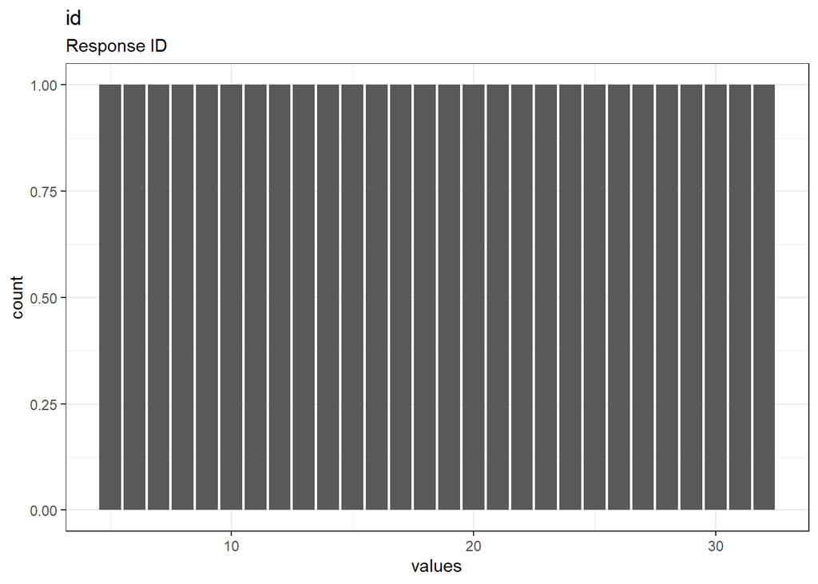

Distribution of values for id

0 missing values.

#### Summary statistics

| name | label | data_type | n_missing | complete_rate | min | median | max | mean | sd | hist | format.spss |
| --- | --- | --- | --- | --- | --- | --- | --- | --- | --- | --- | --- |
| id | Response ID | numeric | 0 | 1 | 5 | 18 | 32 | 18.5 | 8.225975 | ▇▇▇▇▇ | F2.0 |

### submitdate

Date submitted

#### Distribution

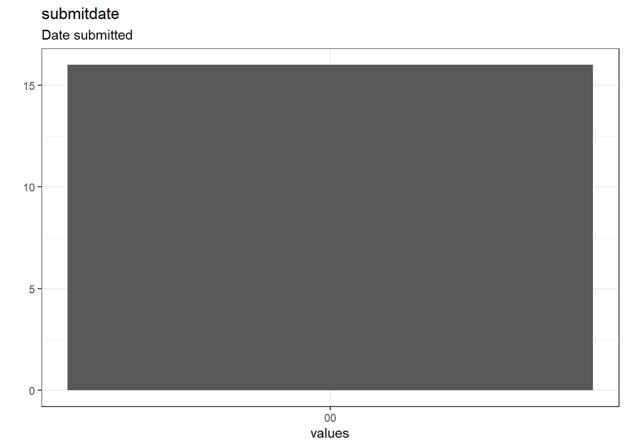

Distribution of values for submitdate

12 missing values.

#### Summary statistics

| name | label | data_type | n_missing | complete_rate | n_unique | min | median | max | format.spss |
| --- | --- | --- | --- | --- | --- | --- | --- | --- | --- |
| submitdate | Date submitted | POSIXct | 12 | 0.5714286 | 1 | 1980-01-01 | 1980-01-01 | 1980-01-01 | DATETIME20 |

### lastpage

Last page

#### Distribution

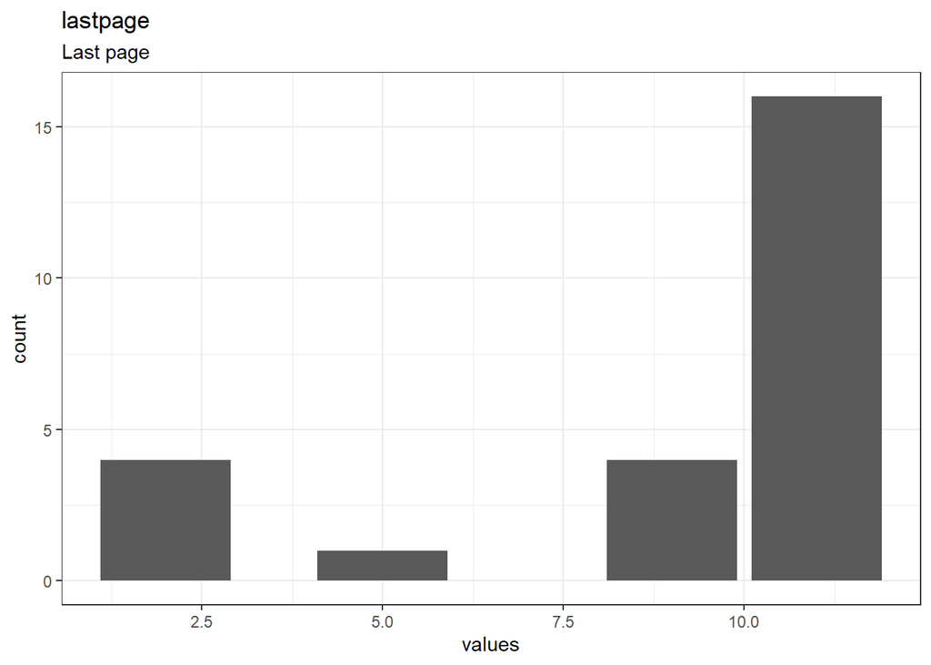

Distribution of values for lastpage

3 missing values.

#### Summary statistics

| name | label | data_type | n_missing | complete_rate | min | median | max | mean | sd | hist | format.spss |
| --- | --- | --- | --- | --- | --- | --- | --- | --- | --- | --- | --- |
| lastpage | Last page | numeric | 3 | 0.8928571 | 2 | 11 | 11 | 9 | 3.391165 | ▂▁▁▂▇ | F2.0 |

### startlanguage

Start language

#### Distribution

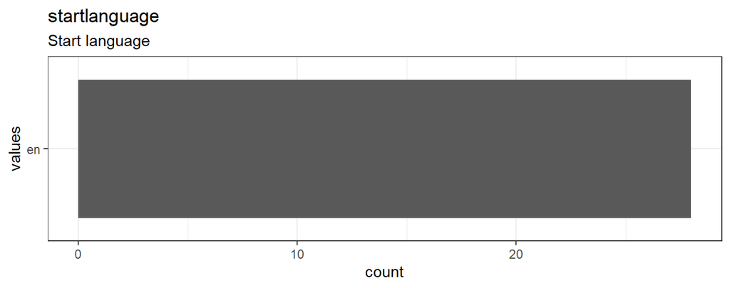

Distribution of values for startlanguage

0 missing values.

#### Summary statistics

| name | label | data_type | n_missing | complete_rate | n_unique | empty | min | max | whitespace | format.spss |
| --- | --- | --- | --- | --- | --- | --- | --- | --- | --- | --- |
| startlanguage | Start language | character | 0 | 1 | 1 | 0 | 2 | 2 | 0 | A2 |

### seed

Seed

#### Distribution

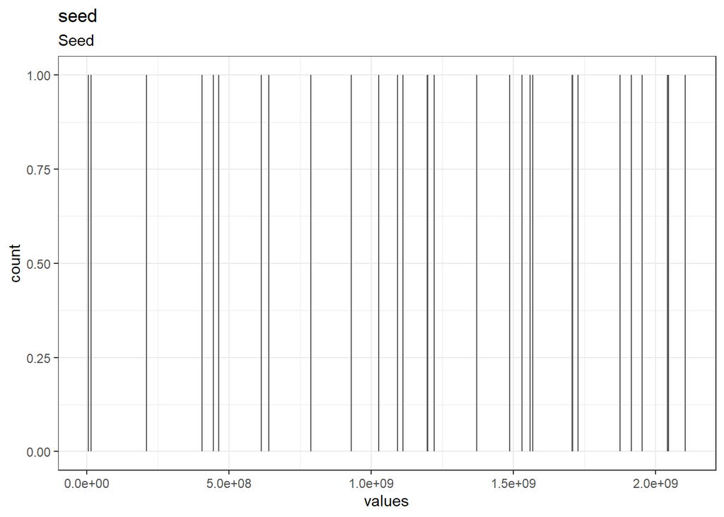

Distribution of values for seed

0 missing values.

#### Summary statistics

| name | label | data_type | n_missing | complete_rate | min | median | max | mean | sd | hist | format.spss |
| --- | --- | --- | --- | --- | --- | --- | --- | --- | --- | --- | --- |
| seed | Seed | numeric | 0 | 1 | 5321115 | 1.2e+09 | 2.1e+09 | 1180732290 | 646987040 | ▃▅▆▅▇ | F10.0 |

### datenschutz

What happens to your data? Information on data protection We work in accordance with the provisions of the European General Data Protection Regulation.The following data will be collected as part of this study: Questionnaire data on… Your perceptio

#### Distribution

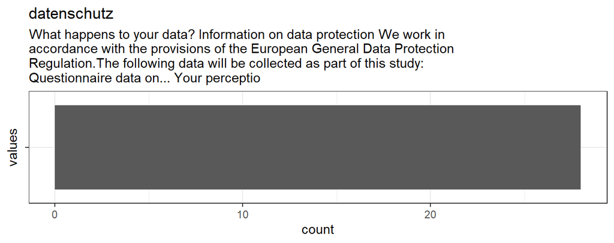

Distribution of values for datenschutz

0 missing values.

#### Summary statistics

| name | label | data_type | n_missing | complete_rate | n_unique | empty | min | max | whitespace | format.spss |
| --- | --- | --- | --- | --- | --- | --- | --- | --- | --- | --- |
| datenschutz | What happens to your data? Information on data protection We work in accordance with the provisions of the European General Data Protection Regulation.The following data will be collected as part of t… | character | 0 | 1 | 1 | 28 | 0 | 0 | 0 | A1 |

### consentInfo_yes

[I acknowledge that I have been informed about the voluntariness of my participation and the details of data protection, and I consent to the processing of my data as described.]

#### Distribution

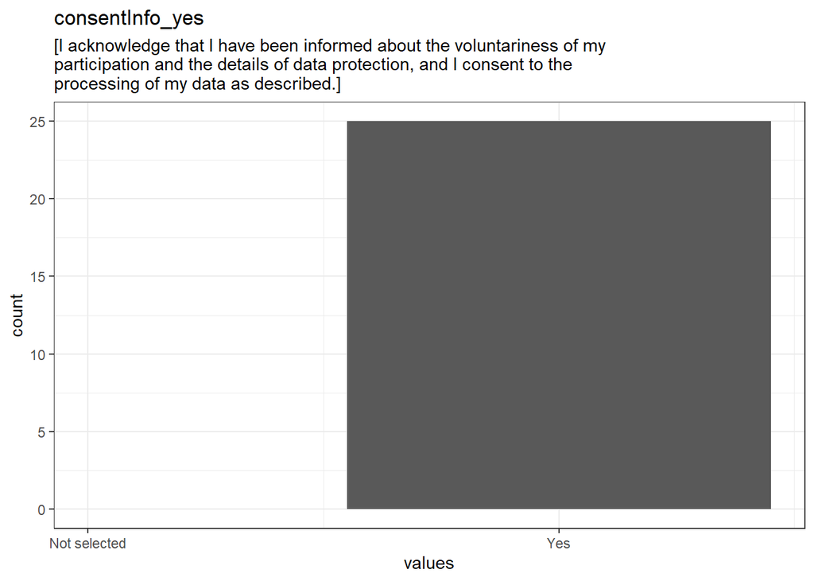

Distribution of values for consentInfo_yes

3 missing values.

#### Summary statistics

| name | label | data_type | n_missing | complete_rate | min | median | max | mean | sd | hist | format.spss |
| --- | --- | --- | --- | --- | --- | --- | --- | --- | --- | --- | --- |
| consentInfo_yes | [I acknowledge that I have been informed about the voluntariness of my participation and the details of data protection, and I consent to the processing of my data as described.] | numeric | 3 | 0.8928571 | 1 | 1 | 1 | 1 | 0 | ▁▁▇▁▁ | F10.0 |

#### Value labels

Response choices

| name | value |
| --- | --- |
| Yes | 1 |
| Not selected | 0 |

### introScenario

On the next page you will find a fictitious scenario that could be taken from the practical experience of a researcher. Please take a moment to put yourself in this situation and answer the following questions as best you can.

#### Distribution

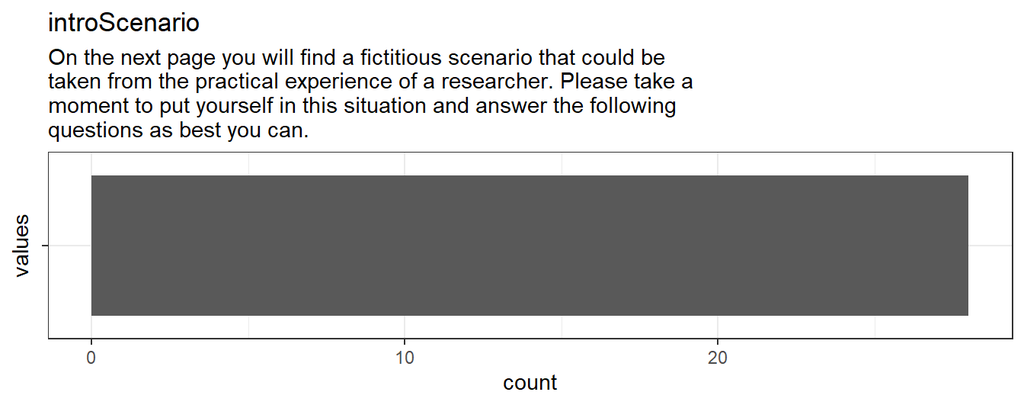

Distribution of values for introScenario

0 missing values.

#### Summary statistics

| name | label | data_type | n_missing | complete_rate | n_unique | empty | min | max | whitespace | format.spss |
| --- | --- | --- | --- | --- | --- | --- | --- | --- | --- | --- |
| introScenario | On the next page you will find a fictitious scenario that could be taken from the practical experience of a researcher. Please take a moment to put yourself in this situation and answer the following … | character | 0 | 1 | 1 | 28 | 0 | 0 | 0 | A1 |

### vignetteVersionA

Consider the following scenario Imagine you are applying for a grant from a research funder to conduct a study on the relationship between students’ self-regulated learning strategies and their academic performance. You plan to administer a survey wit

#### Distribution

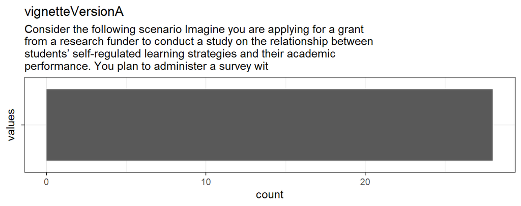

Distribution of values for vignetteVersionA

0 missing values.

#### Summary statistics

| name | label | data_type | n_missing | complete_rate | n_unique | empty | min | max | whitespace | format.spss |
| --- | --- | --- | --- | --- | --- | --- | --- | --- | --- | --- |
| vignetteVersionA | Consider the following scenario Imagine you are applying for a grant from a research funder to conduct a study on the relationship between students’ self-regulated learning strategies and their academ… | character | 0 | 1 | 1 | 28 | 0 | 0 | 0 | A1 |

### experience

How often have you documented and provided the data as well as data analysis in such a way that other researchers can understand and follow the steps to obtain exactly the same results as you?

#### Distribution

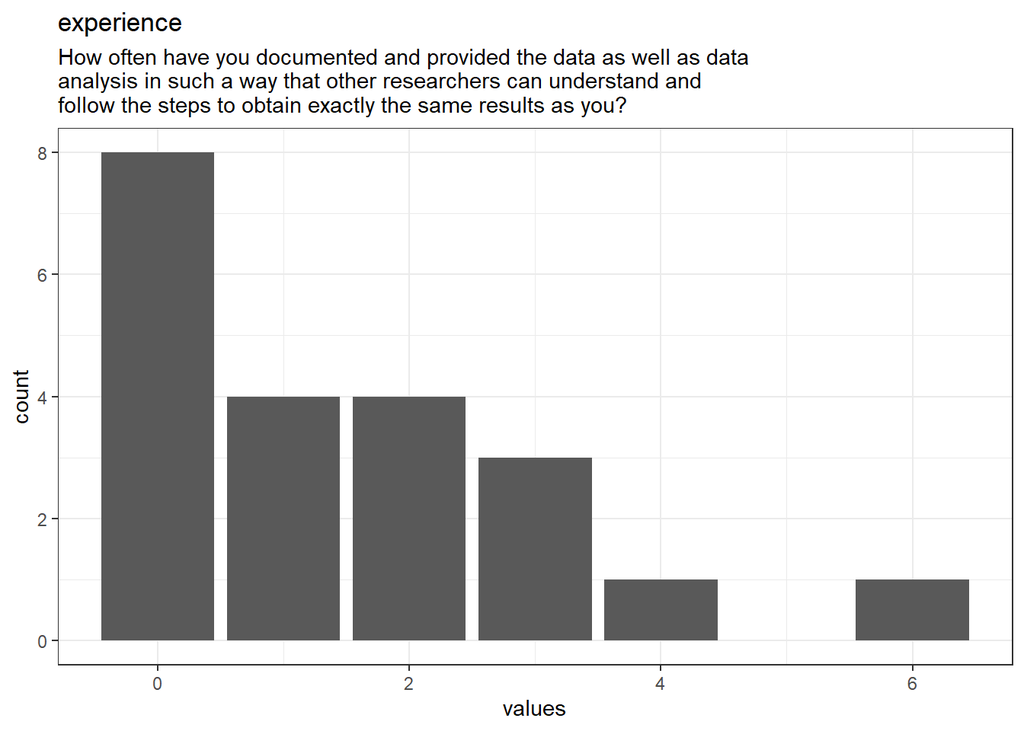

Distribution of values for experience

7 missing values.

#### Summary statistics

| name | label | data_type | n_missing | complete_rate | min | median | max | mean | sd | hist | format.spss |
| --- | --- | --- | --- | --- | --- | --- | --- | --- | --- | --- | --- |
| experience | How often have you documented and provided the data as well as data analysis in such a way that other researchers can understand and follow the steps to obtain exactly the same results as you? | numeric | 7 | 0.75 | 0 | 1 | 6 | 1.47619 | 1.631535 | ▇▂▂▁▁ | F10.0 |

### introText

In the following section, after a set of preliminary questions, you will have the opportunity to read a short informational text on the topic of computational reproducibility, including links to relevant resources. The text describes options and m

#### Distribution

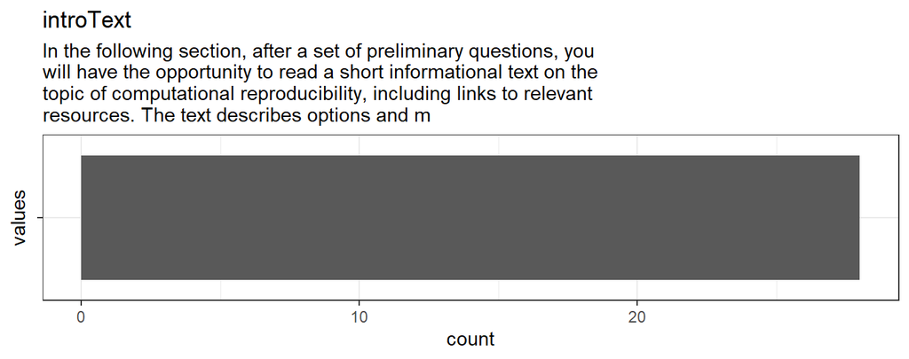

Distribution of values for introText

0 missing values.

#### Summary statistics

| name | label | data_type | n_missing | complete_rate | n_unique | empty | min | max | whitespace | format.spss |
| --- | --- | --- | --- | --- | --- | --- | --- | --- | --- | --- |
| introText | In the following section, after a set of preliminary questions, you will have the opportunity to read a short informational text on the topic of computational reproducibility, including links to relev… | character | 0 | 1 | 1 | 28 | 0 | 0 | 0 | A1 |

### headerExpectations

What are your expectations with regard to the informational text? The text will be shown on the next page.

#### Distribution

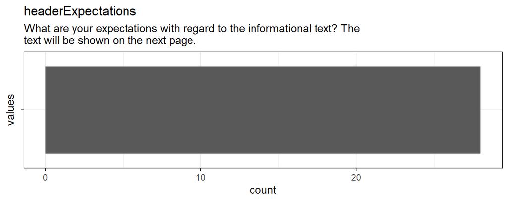

Distribution of values for headerExpectations

0 missing values.

#### Summary statistics

| name | label | data_type | n_missing | complete_rate | n_unique | empty | min | max | whitespace | format.spss |
| --- | --- | --- | --- | --- | --- | --- | --- | --- | --- | --- |
| headerExpectations | What are your expectations with regard to the informational text? The text will be shown on the next page. | character | 0 | 1 | 1 | 28 | 0 | 0 | 0 | A1 |

### infotext

Solutions to promote reproducibility Below you’ll find information on how open file formats and software, Input-Output-Documents (“Notebooks”) and version managemend and containerization promote computational reproducibility in data analysis. A bas

#### Distribution

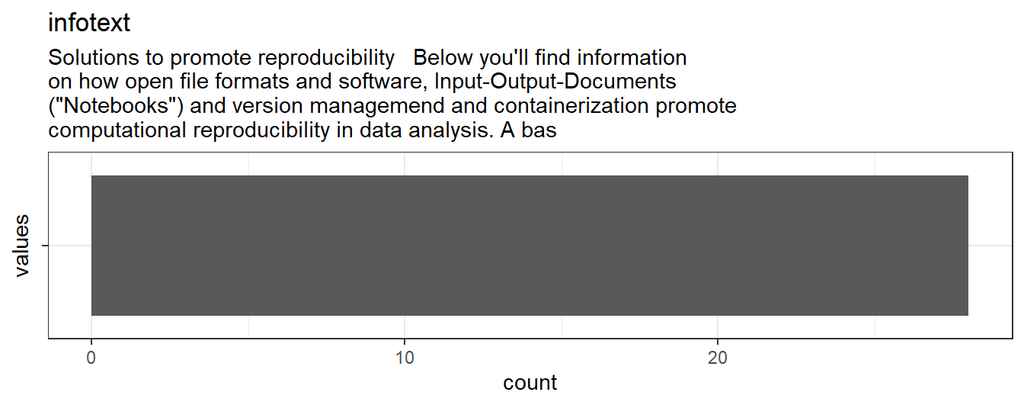

Distribution of values for infotext

0 missing values.

#### Summary statistics

| name | label | data_type | n_missing | complete_rate | n_unique | empty | min | max | whitespace | format.spss |
| --- | --- | --- | --- | --- | --- | --- | --- | --- | --- | --- |
| infotext | Solutions to promote reproducibility Below you’ll find information on how open file formats and software, Input-Output-Documents (“Notebooks”) and version managemend and containerization promote compu… | character | 0 | 1 | 1 | 28 | 0 | 0 | 0 | A1 |

### gender

At the end, we would like to ask you for some demographic information. Gender: How do you identify?

#### Distribution

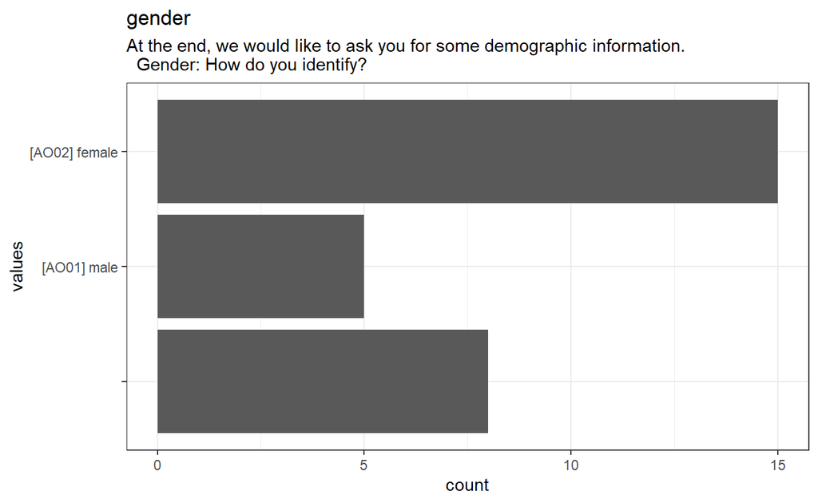

Distribution of values for gender

0 missing values.

#### Summary statistics

| name | label | data_type | n_missing | complete_rate | n_unique | empty | min | max | whitespace | format.spss |
| --- | --- | --- | --- | --- | --- | --- | --- | --- | --- | --- |
| gender | At the end, we would like to ask you for some demographic information. Gender: How do you identify? | character | 0 | 1 | 3 | 8 | 0 | 4 | 0 | A28 |

#### Value labels

Response choices

| name | value |
| --- | --- |
| 1 | AO01 |
| 2 | AO02 |
| 3 | AO03 |

### age

What is your age?

#### Distribution

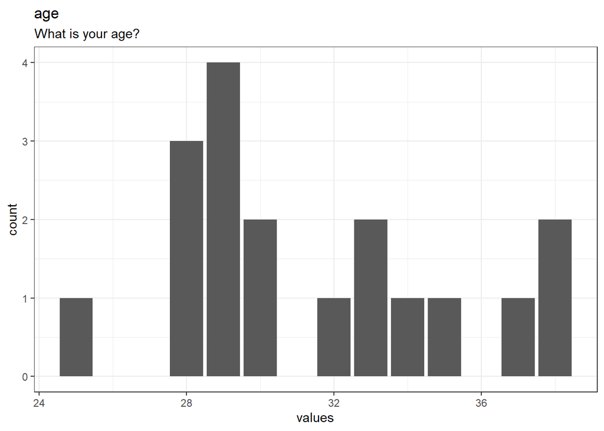

Distribution of values for age

10 missing values.

#### Summary statistics

| name | label | data_type | n_missing | complete_rate | min | median | max | mean | sd | hist | format.spss |
| --- | --- | --- | --- | --- | --- | --- | --- | --- | --- | --- | --- |
| age | What is your age? | numeric | 10 | 0.6428571 | 25 | 30 | 38 | 31.38889 | 3.80617 | ▁▇▁▃▂ | F10.0 |

### country

In which country is your primary workplace located?

#### Distribution

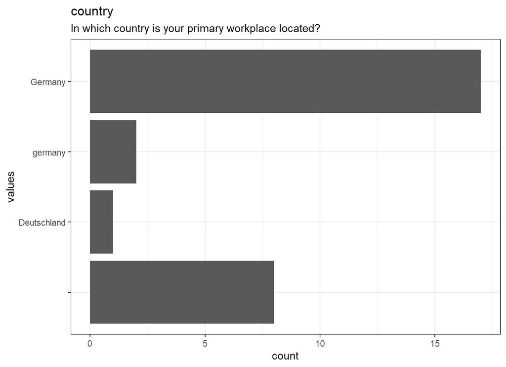

Distribution of values for country

0 missing values.

#### Summary statistics

| name | label | data_type | n_missing | complete_rate | n_unique | empty | min | max | whitespace | format.spss |
| --- | --- | --- | --- | --- | --- | --- | --- | --- | --- | --- |
| country | In which country is your primary workplace located? | character | 0 | 1 | 4 | 8 | 0 | 11 | 0 | A11 |

### careerStage

What is your current career stage in academia?

#### Distribution

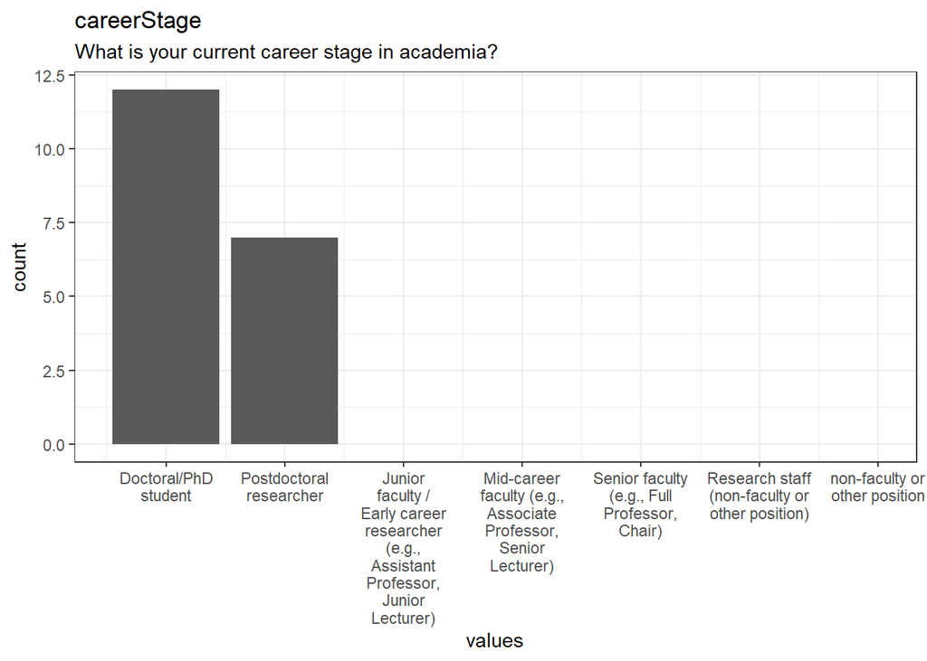

Distribution of values for careerStage

9 missing values.

#### Summary statistics

| name | label | data_type | n_missing | complete_rate | min | median | max | mean | sd | hist | format.spss |
| --- | --- | --- | --- | --- | --- | --- | --- | --- | --- | --- | --- |
| careerStage | What is your current career stage in academia? | numeric | 9 | 0.6785714 | 1 | 1 | 2 | 1.368421 | 0.4955946 | ▇▁▁▁▅ | F10.0 |

#### Value labels

Response choices

| name | value |
| --- | --- |
| Doctoral/PhD student | 1 |
| Postdoctoral researcher | 2 |
| Junior faculty / Early career researcher (e.g., Assistant Professor, Junior Lecturer) | 3 |
| Mid-career faculty (e.g., Associate Professor, Senior Lecturer) | 4 |
| Senior faculty (e.g., Full Professor, Chair) | 5 |
| Research staff (non-faculty or other position) | 6 |
| non-faculty or other position | 7 |

### engageBehavioral

Would you like to download the information text and further practical suggestions on how you can improve the computational reproducibility of your data analyses? Download will be provided on the next page

#### Distribution

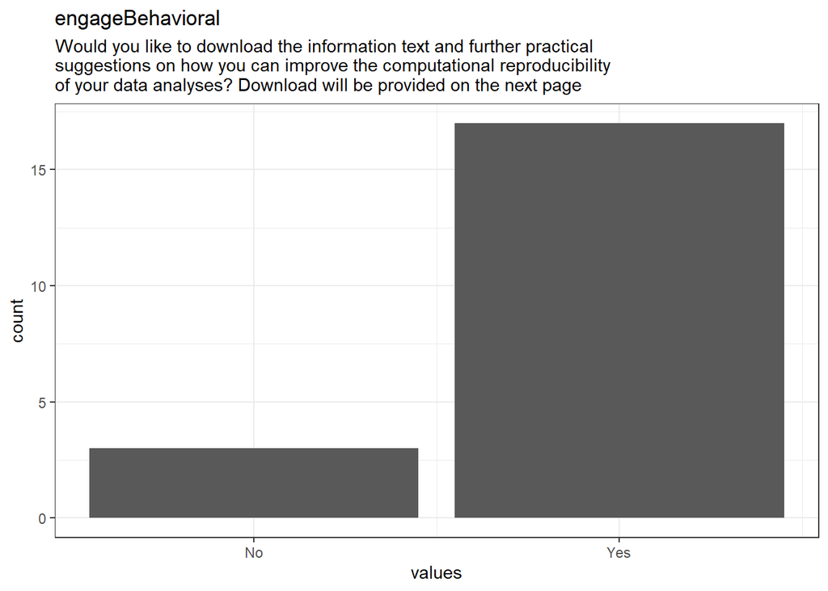

Distribution of values for engageBehavioral

8 missing values.

#### Summary statistics

| name | label | data_type | n_missing | complete_rate | min | median | max | mean | sd | hist | format.spss |
| --- | --- | --- | --- | --- | --- | --- | --- | --- | --- | --- | --- |
| engageBehavioral | Would you like to download the information text and further practical suggestions on how you can improve the computational reproducibility of your data analyses? Download will be provided on the next … | numeric | 8 | 0.7142857 | 0 | 1 | 1 | 0.85 | 0.3663475 | ▂▁▁▁▇ | F10.0 |

#### Value labels

Response choices

| name | value |
| --- | --- |
| Yes | 1 |
| No | 0 |

### downloadText

Download the informational text.

#### Distribution

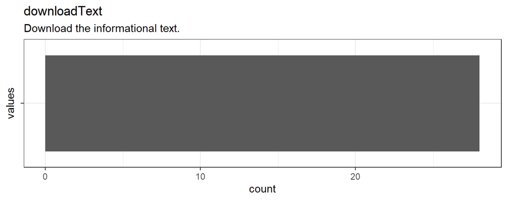

Distribution of values for downloadText

0 missing values.

#### Summary statistics

| name | label | data_type | n_missing | complete_rate | n_unique | empty | min | max | whitespace | format.spss |
| --- | --- | --- | --- | --- | --- | --- | --- | --- | --- | --- |
| downloadText | Download the informational text. | character | 0 | 1 | 1 | 28 | 0 | 0 | 0 | A1 |

### donation

Donation As announced in the invitation email, we will make a donation of … € for each completed survey. You can choose from the following options where this donation should go:

#### Distribution

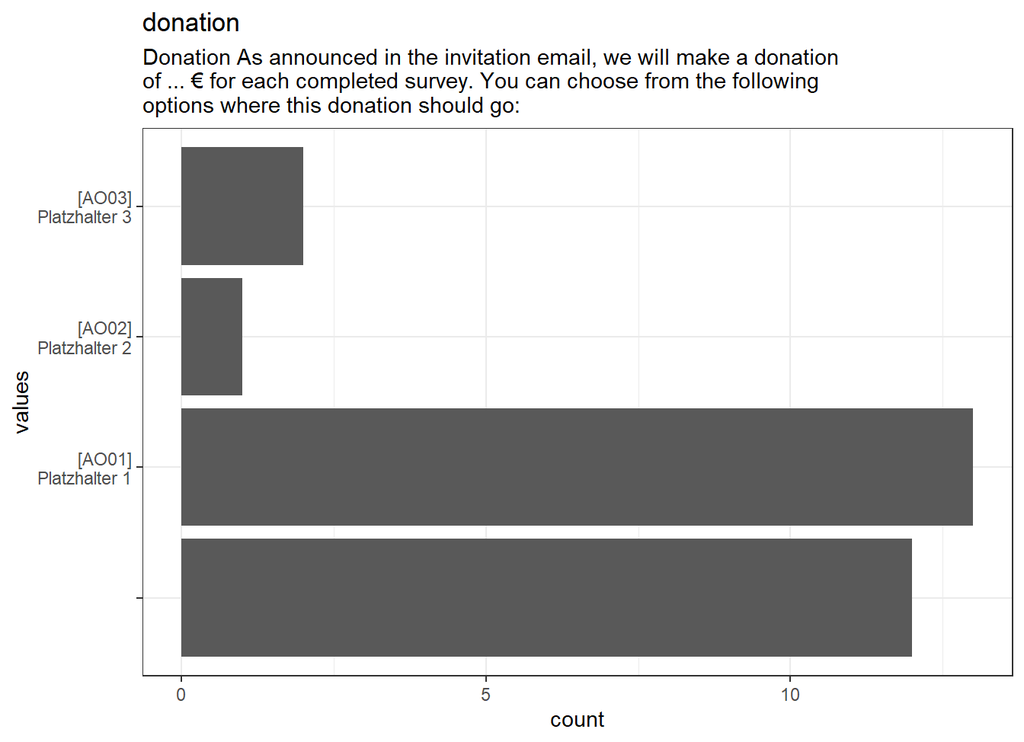

Distribution of values for donation

0 missing values.

#### Summary statistics

| name | label | data_type | n_missing | complete_rate | n_unique | empty | min | max | whitespace | format.spss |
| --- | --- | --- | --- | --- | --- | --- | --- | --- | --- | --- |
| donation | Donation As announced in the invitation email, we will make a donation of … € for each completed survey. You can choose from the following options where this donation should go: | character | 0 | 1 | 4 | 12 | 0 | 4 | 0 | A28 |

#### Value labels

Response choices

| name | value |
| --- | --- |
| 1 | AO01 |
| 2 | AO02 |
| 3 | AO03 |
| 4 | AO04 |

### Scale: resourcePerson_va

#### Overview

**Reliability**: Cronbach’s α [95% CI] = 0.95 [0.92;0.98].

**Missing**: 7.

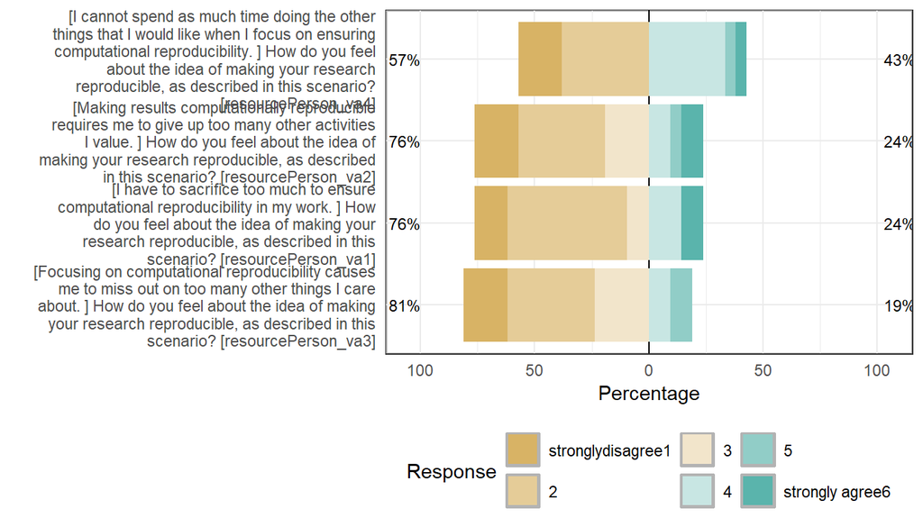

Likert plot of scale resourcePerson_va items

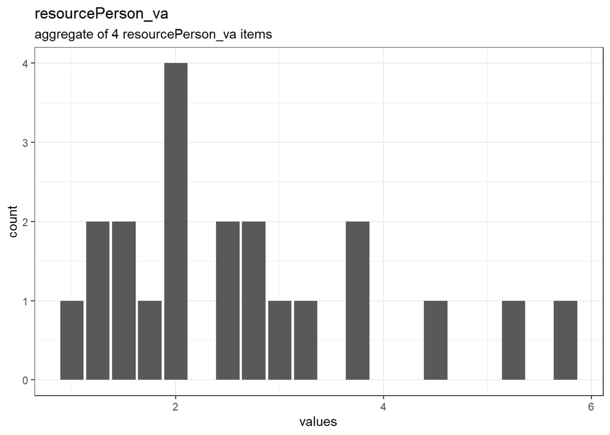

Distribution of scale resourcePerson_va

#### Reliability details

###### Reliability

###### 95% Confidence Interval

| lower | estimate | upper |
| --- | --- | --- |
| 0.9173166 | 0.9480154 | 0.9787142 |

|  | raw_alpha | std.alpha | G6(smc) | average_r | S/N | ase | mean | sd | median_r |
| --- | --- | --- | --- | --- | --- | --- | --- | --- | --- |
|  | 0.9480154 | 0.9494968 | 0.9499544 | 0.824567 | 18.80073 | 0.0156627 | 2.666667 | 1.314185 | 0.8304587 |

###### Reliability if an item is dropped:

|  | raw_alpha | std.alpha | G6(smc) | average_r | S/N | alpha se | var.r | med.r |
| --- | --- | --- | --- | --- | --- | --- | --- | --- |
| resourcePerson_va4 | 0.9515695 | 0.9543584 | 0.9454078 | 0.8745287 | 20.909856 | 0.0149044 | 0.0036289 | 0.8737485 |
| resourcePerson_va3 | 0.9448947 | 0.9448787 | 0.9392928 | 0.8510561 | 17.141808 | 0.0188945 | 0.0066905 | 0.8462352 |
| resourcePerson_va1 | 0.9233970 | 0.9268665 | 0.9180704 | 0.8085956 | 12.673618 | 0.0242315 | 0.0081140 | 0.8462352 |
| resourcePerson_va2 | 0.9029078 | 0.9066867 | 0.8724435 | 0.7640877 | 9.716589 | 0.0312185 | 0.0030080 | 0.7717777 |

###### Item statistics

|  | n | raw.r | std.r | r.cor | r.drop | mean | sd |
| --- | --- | --- | --- | --- | --- | --- | --- |
| resourcePerson_va4 | 21 | 0.8970304 | 0.8916835 | 0.8389153 | 0.8130958 | 2.809524 | 1.470342 |
| resourcePerson_va3 | 21 | 0.9020508 | 0.9105746 | 0.8702826 | 0.8414049 | 2.523810 | 1.209092 |
| resourcePerson_va1 | 21 | 0.9460964 | 0.9447474 | 0.9351727 | 0.9013034 | 2.619048 | 1.430950 |
| resourcePerson_va2 | 21 | 0.9816226 | 0.9805679 | 0.9887312 | 0.9640377 | 2.714286 | 1.521278 |

###### Non missing response frequency for each item

|  | 1 | 2 | 3 | 4 | 5 | 6 | miss |
| --- | --- | --- | --- | --- | --- | --- | --- |
| resourcePerson_va4 | 0.1904762 | 0.3809524 | 0.0000000 | 0.3333333 | 0.0476190 | 0.0476190 | 0.25 |
| resourcePerson_va3 | 0.1904762 | 0.3809524 | 0.2380952 | 0.0952381 | 0.0952381 | 0.0000000 | 0.25 |
| resourcePerson_va1 | 0.1428571 | 0.5238095 | 0.0952381 | 0.1428571 | 0.0000000 | 0.0952381 | 0.25 |
| resourcePerson_va2 | 0.1904762 | 0.3809524 | 0.1904762 | 0.0952381 | 0.0476190 | 0.0952381 | 0.25 |

#### Summary statistics

| name | label | data_type | value_labels | n_missing | complete_rate | min | median | max | mean | sd | hist | format.spss |
| --- | --- | --- | --- | --- | --- | --- | --- | --- | --- | --- | --- | --- |
| resourcePerson_va4 | [I cannot spend as much time doing the other things that I would like when I focus on ensuring computational reproducibility. ] How do you feel about the idea of making your research reproducible, as … | numeric | 1. stronglydisagree1, 2. 2, 3. 3, 4. 4, 5. 5, 6. strongly agree6 | 7 | 0.75 | 1 | 2 | 6 | 2.809524 | 1.470342 | ▇▁▅▁▁ | F10.0 |
| resourcePerson_va3 | [Focusing on computational reproducibility causes me to miss out on too many other things I care about. ] How do you feel about the idea of making your research reproducible, as described in this scen… | numeric | 1. stronglydisagree1, 2. 2, 3. 3, 4. 4, 5. 5, 6. strongly agree6 | 7 | 0.75 | 1 | 2 | 5 | 2.523810 | 1.209092 | ▃▇▅▂▂ | F10.0 |
| resourcePerson_va1 | [I have to sacrifice too much to ensure computational reproducibility in my work. ] How do you feel about the idea of making your research reproducible, as described in this scenario? | numeric | 1. stronglydisagree1, 2. 2, 3. 3, 4. 4, 5. 5, 6. strongly agree6 | 7 | 0.75 | 1 | 2 | 6 | 2.619048 | 1.430950 | ▇▁▂▁▁ | F10.0 |
| resourcePerson_va2 | [Making results computationally reproducible requires me to give up too many other activities I value. ] How do you feel about the idea of making your research reproducible, as described in this scena… | numeric | 1. stronglydisagree1, 2. 2, 3. 3, 4. 4, 5. 5, 6. strongly agree6 | 7 | 0.75 | 1 | 2 | 6 | 2.714286 | 1.521278 | ▇▂▁▁▁ | F10.0 |

### Scale: resourcePerson_eos

#### Overview

**Reliability**: Cronbach’s α [95% CI] = 0.81 [0.7;0.92].

**Missing**: 7.

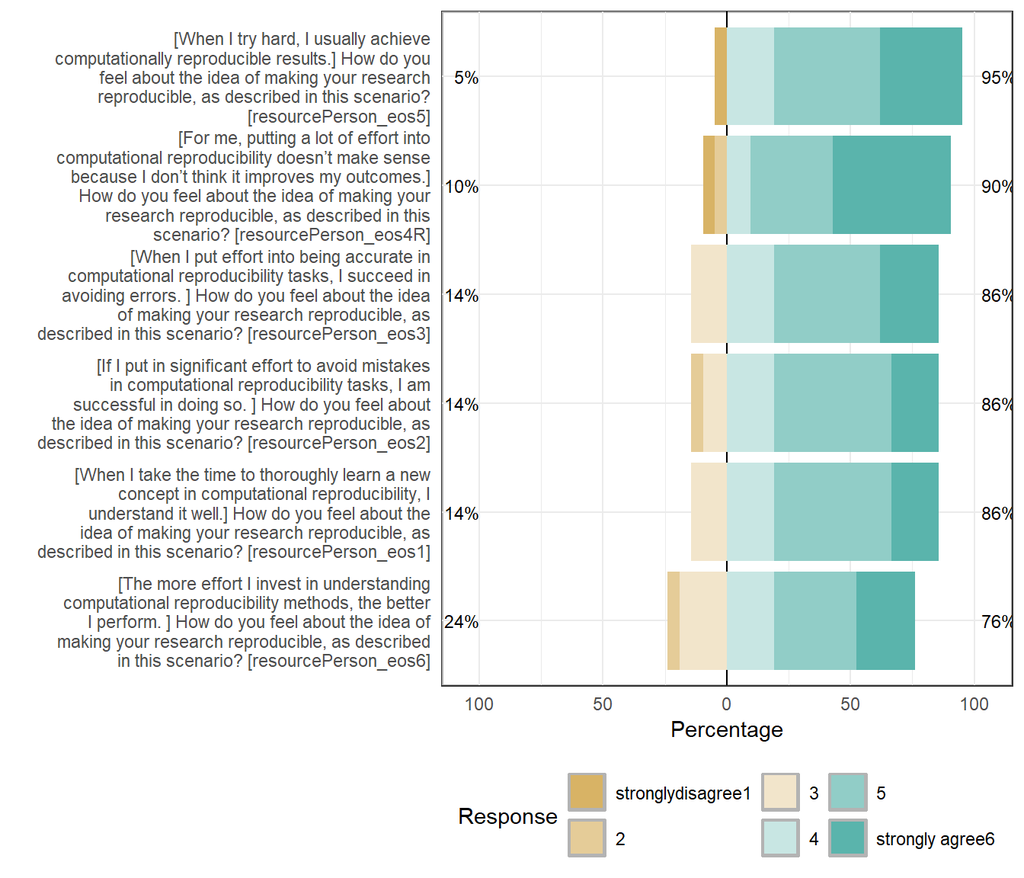

Likert plot of scale resourcePerson_eos items

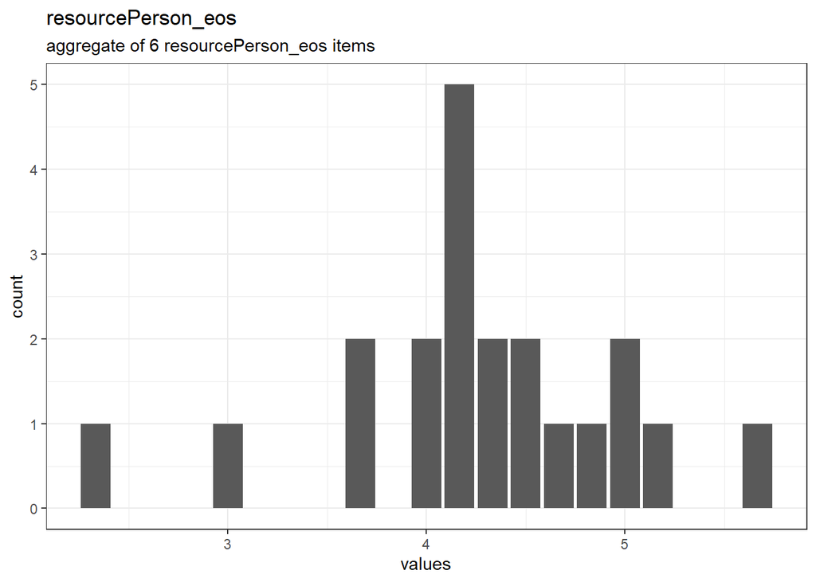

Distribution of scale resourcePerson_eos

#### Reliability details

###### Reliability

###### 95% Confidence Interval

| lower | estimate | upper |
| --- | --- | --- |
| 0.6976504 | 0.8109149 | 0.9241795 |

|  | raw_alpha | std.alpha | G6(smc) | average_r | S/N | ase | mean | sd | median_r |
| --- | --- | --- | --- | --- | --- | --- | --- | --- | --- |
|  | 0.8109149 | 0.8320703 | 0.872441 | 0.4522986 | 4.954874 | 0.057788 | 4.777778 | 0.8119478 | 0.5173774 |

###### Reliability if an item is dropped:

|  | raw_alpha | std.alpha | G6(smc) | average_r | S/N | alpha se | var.r | med.r |
| --- | --- | --- | --- | --- | --- | --- | --- | --- |
| resourcePerson_eos6 | 0.7785941 | 0.8075915 | 0.8517196 | 0.4563607 | 4.197275 | 0.0706525 | 0.0854475 | 0.6083649 |
| resourcePerson_eos1 | 0.7377698 | 0.7604403 | 0.7940642 | 0.3883287 | 3.174324 | 0.0815048 | 0.0679112 | 0.3889465 |
| resourcePerson_eos2 | 0.7617630 | 0.7902719 | 0.8206319 | 0.4297497 | 3.768079 | 0.0745977 | 0.0775664 | 0.4793083 |
| resourcePerson_eos3 | 0.7680723 | 0.7904257 | 0.8164703 | 0.4299771 | 3.771577 | 0.0724973 | 0.0545466 | 0.4270157 |
| resourcePerson_eos5 | 0.7450758 | 0.7740475 | 0.8201314 | 0.4065781 | 3.425709 | 0.0800874 | 0.0621359 | 0.3889465 |
| resourcePerson_eos4R | 0.8779690 | 0.8835589 | 0.8891673 | 0.6027974 | 7.588033 | 0.0375808 | 0.0182972 | 0.6792796 |

###### Item statistics

|  | n | raw.r | std.r | r.cor | r.drop | mean | sd |
| --- | --- | --- | --- | --- | --- | --- | --- |
| resourcePerson_eos6 | 21 | 0.7356702 | 0.7280975 | 0.6594287 | 0.5841452 | 4.523809 | 1.2090925 |
| resourcePerson_eos1 | 21 | 0.8694301 | 0.8818882 | 0.8829126 | 0.8061721 | 4.714286 | 0.9561829 |
| resourcePerson_eos2 | 21 | 0.7776889 | 0.7882535 | 0.7559302 | 0.6646064 | 4.666667 | 1.0645813 |
| resourcePerson_eos3 | 21 | 0.7562581 | 0.7877394 | 0.7683727 | 0.6448211 | 4.761905 | 0.9952267 |
| resourcePerson_eos5 | 21 | 0.8281178 | 0.8406342 | 0.8218282 | 0.7248664 | 4.952381 | 1.1608700 |
| resourcePerson_eos4R | 21 | 0.4480053 | 0.3970687 | 0.2434473 | 0.1857323 | 5.047619 | 1.3592715 |

###### Non missing response frequency for each item

|  | 1 | 2 | 3 | 4 | 5 | 6 | miss |
| --- | --- | --- | --- | --- | --- | --- | --- |
| resourcePerson_eos6 | 0.000000 | 0.047619 | 0.1904762 | 0.1904762 | 0.3333333 | 0.2380952 | 0.25 |
| resourcePerson_eos1 | 0.000000 | 0.000000 | 0.1428571 | 0.1904762 | 0.4761905 | 0.1904762 | 0.25 |
| resourcePerson_eos2 | 0.000000 | 0.047619 | 0.0952381 | 0.1904762 | 0.4761905 | 0.1904762 | 0.25 |
| resourcePerson_eos3 | 0.000000 | 0.000000 | 0.1428571 | 0.1904762 | 0.4285714 | 0.2380952 | 0.25 |
| resourcePerson_eos5 | 0.047619 | 0.000000 | 0.0000000 | 0.1904762 | 0.4285714 | 0.3333333 | 0.25 |
| resourcePerson_eos4R | 0.047619 | 0.047619 | 0.0000000 | 0.0952381 | 0.3333333 | 0.4761905 | 0.25 |

#### Summary statistics

| name | label | data_type | value_labels | n_missing | complete_rate | min | median | max | mean | sd | hist | format.spss |
| --- | --- | --- | --- | --- | --- | --- | --- | --- | --- | --- | --- | --- |
| resourcePerson_eos6 | [The more effort I invest in understanding computational reproducibility methods, the better I perform. ] How do you feel about the idea of making your research reproducible, as described in this scen… | numeric | 1. stronglydisagree1, 2. 2, 3. 3, 4. 4, 5. 5, 6. strongly agree6 | 7 | 0.75 | 2 | 5 | 6 | 4.523809 | 1.2090925 | ▁▅▅▇▆ | F10.0 |
| resourcePerson_eos1 | [When I take the time to thoroughly learn a new concept in computational reproducibility, I understand it well.] How do you feel about the idea of making your research reproducible, as described in th… | numeric | 1. stronglydisagree1, 2. 2, 3. 3, 4. 4, 5. 5, 6. strongly agree6 | 7 | 0.75 | 3 | 5 | 6 | 4.714286 | 0.9561829 | ▂▃▁▇▃ | F10.0 |
| resourcePerson_eos2 | [If I put in significant effort to avoid mistakes in computational reproducibility tasks, I am successful in doing so. ] How do you feel about the idea of making your research reproducible, as describ… | numeric | 1. stronglydisagree1, 2. 2, 3. 3, 4. 4, 5. 5, 6. strongly agree6 | 7 | 0.75 | 2 | 5 | 6 | 4.666667 | 1.0645813 | ▁▂▃▇▃ | F10.0 |
| resourcePerson_eos3 | [When I put effort into being accurate in computational reproducibility tasks, I succeed in avoiding errors. ] How do you feel about the idea of making your research reproducible, as described in this… | numeric | 1. stronglydisagree1, 2. 2, 3. 3, 4. 4, 5. 5, 6. strongly agree6 | 7 | 0.75 | 3 | 5 | 6 | 4.761905 | 0.9952267 | ▂▃▁▇▅ | F10.0 |
| resourcePerson_eos5 | [When I try hard, I usually achieve computationally reproducible results.] How do you feel about the idea of making your research reproducible, as described in this scenario? | numeric | 1. stronglydisagree1, 2. 2, 3. 3, 4. 4, 5. 5, 6. strongly agree6 | 7 | 0.75 | 1 | 5 | 6 | 4.952381 | 1.1608700 | ▁▁▃▇▆ | F10.0 |
| resourcePerson_eos4R | [For me, putting a lot of effort into computational reproducibility doesn’t make sense because I don’t think it improves my outcomes.] How do you feel about the idea of making your research reproducib… | numeric | 6. stronglydisagree1, 5. 2, 4. 3, 3. 4, 2. 5, 1. strongly agree6 | 7 | 0.75 | 1 | 5 | 6 | 5.047619 | 1.3592715 | ▂▁▂▆▇ | F10.0 |

### Scale: implicates_self

#### Overview

**Reliability**: Cronbach’s α [95% CI] = 0.87 [0.8;0.95].

**Missing**: 8.

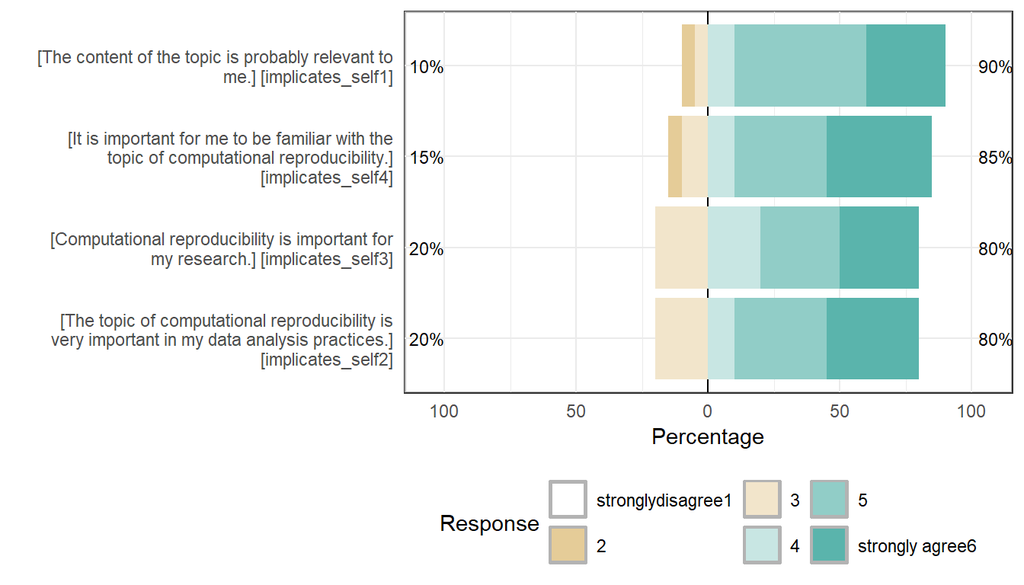

Likert plot of scale implicates_self items

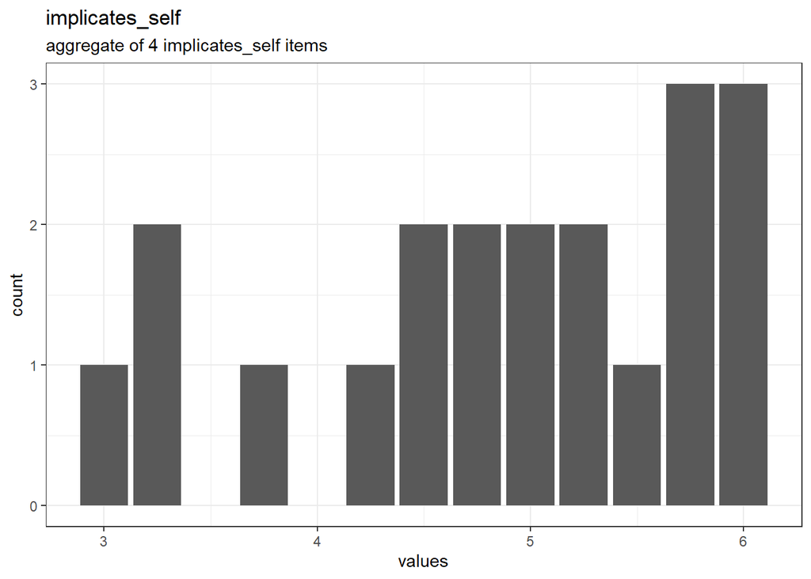

Distribution of scale implicates_self

#### Reliability details

###### Reliability

###### 95% Confidence Interval

| lower | estimate | upper |
| --- | --- | --- |
| 0.7967483 | 0.8746515 | 0.9525546 |

|  | raw_alpha | std.alpha | G6(smc) | average_r | S/N | ase | mean | sd | median_r |
| --- | --- | --- | --- | --- | --- | --- | --- | --- | --- |
|  | 0.8746515 | 0.871267 | 0.9147301 | 0.6285295 | 6.768015 | 0.0397465 | 4.8625 | 0.9613416 | 0.6455098 |

###### Reliability if an item is dropped:

|  | raw_alpha | std.alpha | G6(smc) | average_r | S/N | alpha se | var.r | med.r |
| --- | --- | --- | --- | --- | --- | --- | --- | --- |
| implicates_self1 | 0.9350746 | 0.9359034 | 0.9176529 | 0.8295595 | 14.601454 | 0.0220884 | 0.0048458 | 0.8105894 |
| implicates_self2 | 0.8102679 | 0.8080865 | 0.7706142 | 0.5839505 | 4.210681 | 0.0624546 | 0.0272168 | 0.5196204 |
| implicates_self3 | 0.7742905 | 0.7679278 | 0.7721161 | 0.5244891 | 3.309004 | 0.0750372 | 0.0676933 | 0.4608321 |
| implicates_self4 | 0.8076159 | 0.8030509 | 0.8730790 | 0.5761187 | 4.077454 | 0.0672405 | 0.0937927 | 0.5196204 |

###### Item statistics

|  | n | raw.r | std.r | r.cor | r.drop | mean | sd |
| --- | --- | --- | --- | --- | --- | --- | --- |
| implicates_self1 | 20 | 0.6575891 | 0.6718360 | 0.5524224 | 0.4546027 | 4.95 | 1.050063 |
| implicates_self2 | 20 | 0.8952425 | 0.8887154 | 0.8985490 | 0.8026580 | 4.85 | 1.136708 |
| implicates_self3 | 20 | 0.9423209 | 0.9412215 | 0.9503229 | 0.8887154 | 4.70 | 1.128576 |
| implicates_self4 | 20 | 0.9015692 | 0.8956311 | 0.8480347 | 0.8073082 | 4.95 | 1.190975 |

###### Non missing response frequency for each item

|  | 2 | 3 | 4 | 5 | 6 | miss |
| --- | --- | --- | --- | --- | --- | --- |
| implicates_self1 | 0.05 | 0.05 | 0.1 | 0.50 | 0.30 | 0.2857143 |
| implicates_self2 | 0.00 | 0.20 | 0.1 | 0.35 | 0.35 | 0.2857143 |
| implicates_self3 | 0.00 | 0.20 | 0.2 | 0.30 | 0.30 | 0.2857143 |
| implicates_self4 | 0.05 | 0.10 | 0.1 | 0.35 | 0.40 | 0.2857143 |

#### Summary statistics

| name | label | data_type | value_labels | n_missing | complete_rate | min | median | max | mean | sd | hist | format.spss |
| --- | --- | --- | --- | --- | --- | --- | --- | --- | --- | --- | --- | --- |
| implicates_self1 | [The content of the topic is probably relevant to me.] | numeric | 1. stronglydisagree1, 2. 2, 3. 3, 4. 4, 5. 5, 6. strongly agree6 | 8 | 0.7142857 | 2 | 5 | 6 | 4.95 | 1.050063 | ▁▁▂▇▅ | F10.0 |
| implicates_self2 | [The topic of computational reproducibility is very important in my data analysis practices.] | numeric | 1. stronglydisagree1, 2. 2, 3. 3, 4. 4, 5. 5, 6. strongly agree6 | 8 | 0.7142857 | 3 | 5 | 6 | 4.85 | 1.136708 | ▅▂▁▇▇ | F10.0 |
| implicates_self3 | [Computational reproducibility is important for my research.] | numeric | 1. stronglydisagree1, 2. 2, 3. 3, 4. 4, 5. 5, 6. strongly agree6 | 8 | 0.7142857 | 3 | 5 | 6 | 4.70 | 1.128576 | ▅▅▁▇▇ | F10.0 |
| implicates_self4 | [It is important for me to be familiar with the topic of computational reproducibility.] | numeric | 1. stronglydisagree1, 2. 2, 3. 3, 4. 4, 5. 5, 6. strongly agree6 | 8 | 0.7142857 | 2 | 5 | 6 | 4.95 | 1.190975 | ▁▂▂▇▇ | F10.0 |

### Scale: challenge

#### Overview

**Reliability**: Cronbach’s α [95% CI] = 0.83 [0.72;0.93].

**Missing**: 8.

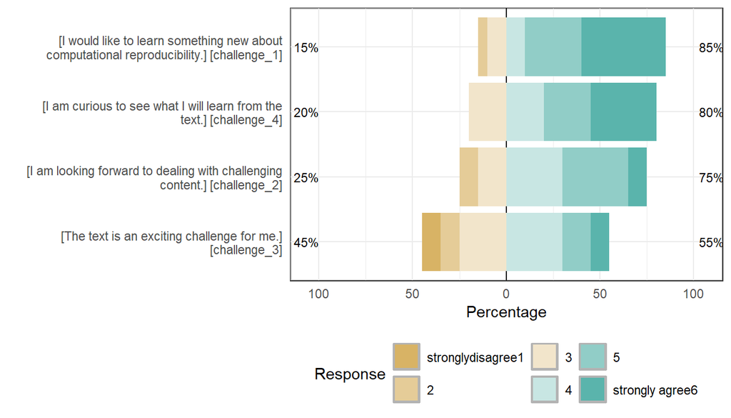

Likert plot of scale challenge items

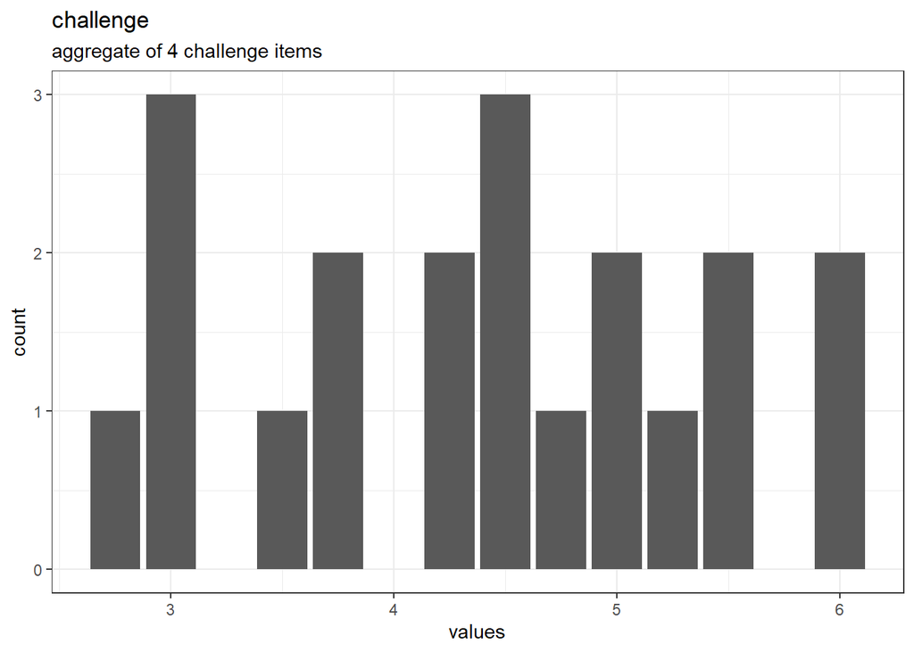

Distribution of scale challenge

#### Reliability details

###### Reliability

###### 95% Confidence Interval

| lower | estimate | upper |
| --- | --- | --- |
| 0.7230289 | 0.828429 | 0.9338291 |

|  | raw_alpha | std.alpha | G6(smc) | average_r | S/N | ase | mean | sd | median_r |
| --- | --- | --- | --- | --- | --- | --- | --- | --- | --- |
|  | 0.828429 | 0.8316825 | 0.8691652 | 0.5526304 | 4.941154 | 0.0537756 | 4.3875 | 1.011366 | 0.5478486 |

###### Reliability if an item is dropped:

|  | raw_alpha | std.alpha | G6(smc) | average_r | S/N | alpha se | var.r | med.r |
| --- | --- | --- | --- | --- | --- | --- | --- | --- |
| challenge_1 | 0.7798877 | 0.7856208 | 0.7131183 | 0.5498626 | 3.664632 | 0.0707670 | 0.0026117 | 0.5495904 |
| challenge_2 | 0.8468596 | 0.8578355 | 0.8372112 | 0.6679250 | 6.034103 | 0.0533132 | 0.0274449 | 0.6011033 |
| challenge_3 | 0.7906559 | 0.7901488 | 0.8588154 | 0.5565594 | 3.765281 | 0.0735709 | 0.0879610 | 0.5495904 |
| challenge_4 | 0.7032333 | 0.6988675 | 0.6405580 | 0.4361747 | 2.320797 | 0.0937668 | 0.0229137 | 0.4988942 |

###### Item statistics

|  | n | raw.r | std.r | r.cor | r.drop | mean | sd |
| --- | --- | --- | --- | --- | --- | --- | --- |
| challenge_1 | 20 | 0.8144966 | 0.8176986 | 0.8133586 | 0.6634367 | 5.00 | 1.213954 |
| challenge_2 | 20 | 0.6981406 | 0.7090726 | 0.6032859 | 0.5000924 | 4.20 | 1.151658 |
| challenge_3 | 20 | 0.8321183 | 0.8115371 | 0.6843719 | 0.6535468 | 3.60 | 1.429023 |
| challenge_4 | 20 | 0.9135953 | 0.9222999 | 0.9388170 | 0.8385432 | 4.75 | 1.164158 |

###### Non missing response frequency for each item

|  | 1 | 2 | 3 | 4 | 5 | 6 | miss |
| --- | --- | --- | --- | --- | --- | --- | --- |
| challenge_1 | 0.0 | 0.05 | 0.10 | 0.1 | 0.30 | 0.45 | 0.2857143 |
| challenge_2 | 0.0 | 0.10 | 0.15 | 0.3 | 0.35 | 0.10 | 0.2857143 |
| challenge_3 | 0.1 | 0.10 | 0.25 | 0.3 | 0.15 | 0.10 | 0.2857143 |
| challenge_4 | 0.0 | 0.00 | 0.20 | 0.2 | 0.25 | 0.35 | 0.2857143 |

#### Summary statistics

| name | label | data_type | value_labels | n_missing | complete_rate | min | median | max | mean | sd | hist | format.spss |
| --- | --- | --- | --- | --- | --- | --- | --- | --- | --- | --- | --- | --- |
| challenge_1 | [I would like to learn something new about computational reproducibility.] | numeric | 1. stronglydisagree1, 2. 2, 3. 3, 4. 4, 5. 5, 6. strongly agree6 | 8 | 0.7142857 | 2 | 5 | 6 | 5.00 | 1.213954 | ▁▂▂▅▇ | F10.0 |
| challenge_2 | [I am looking forward to dealing with challenging content.] | numeric | 1. stronglydisagree1, 2. 2, 3. 3, 4. 4, 5. 5, 6. strongly agree6 | 8 | 0.7142857 | 2 | 4 | 6 | 4.20 | 1.151658 | ▂▃▇▇▂ | F10.0 |
| challenge_3 | [The text is an exciting challenge for me.] | numeric | 1. stronglydisagree1, 2. 2, 3. 3, 4. 4, 5. 5, 6. strongly agree6 | 8 | 0.7142857 | 1 | 4 | 6 | 3.60 | 1.429023 | ▅▇▇▃▂ | F10.0 |
| challenge_4 | [I am curious to see what I will learn from the text.] | numeric | 1. stronglydisagree1, 2. 2, 3. 3, 4. 4, 5. 5, 6. strongly agree6 | 8 | 0.7142857 | 3 | 5 | 6 | 4.75 | 1.164158 | ▅▅▁▆▇ | F10.0 |

### Scale: threat

#### Overview

**Reliability**: Cronbach’s α [95% CI] = 0.94 [0.9;0.98].

**Missing**: 8.

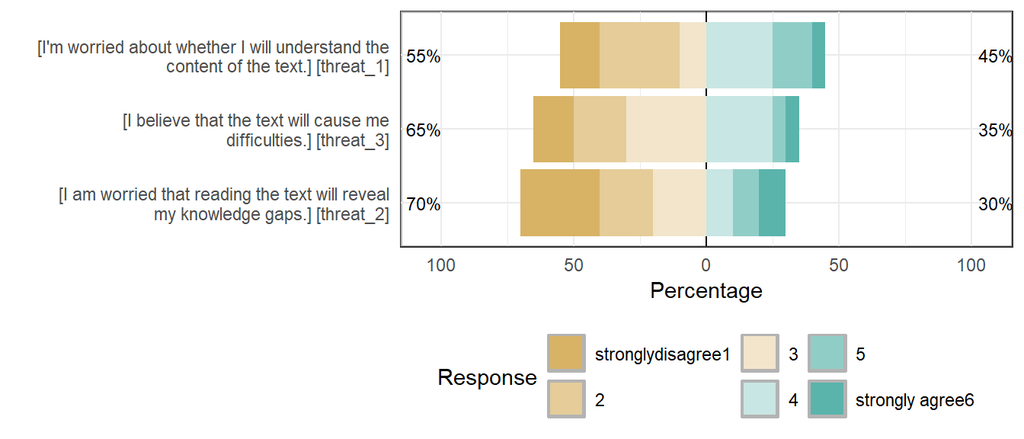

Likert plot of scale threat items

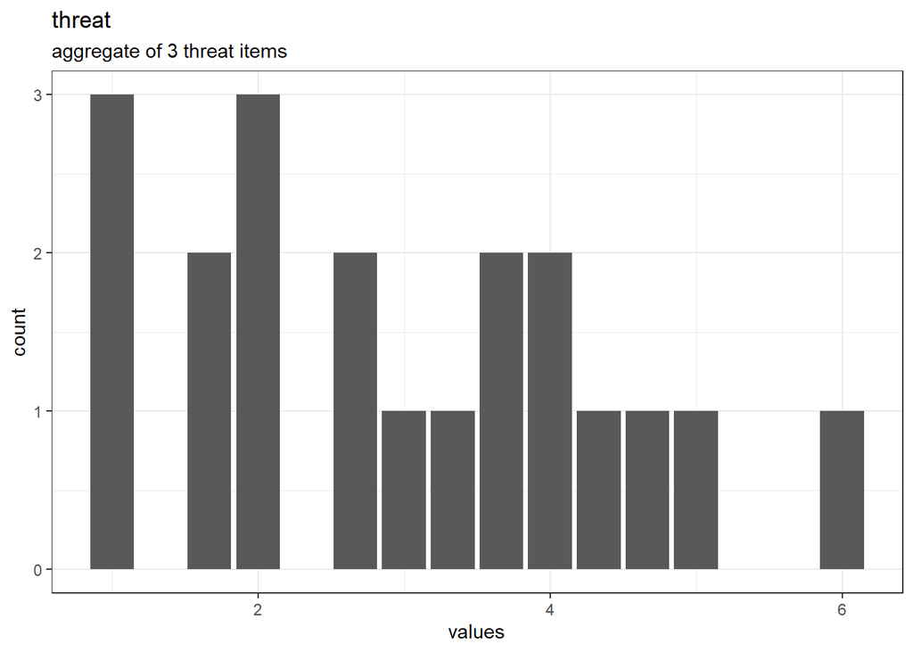

Distribution of scale threat

#### Reliability details

###### Reliability

###### 95% Confidence Interval

| lower | estimate | upper |
| --- | --- | --- |
| 0.8970239 | 0.9361221 | 0.9752203 |

|  | raw_alpha | std.alpha | G6(smc) | average_r | S/N | ase | mean | sd | median_r |
| --- | --- | --- | --- | --- | --- | --- | --- | --- | --- |
|  | 0.9361221 | 0.9410417 | 0.9166045 | 0.8417816 | 15.96113 | 0.019948 | 2.966667 | 1.438404 | 0.8551404 |

###### Reliability if an item is dropped:

|  | raw_alpha | std.alpha | G6(smc) | average_r | S/N | alpha se | var.r | med.r |
| --- | --- | --- | --- | --- | --- | --- | --- | --- |
| threat_1 | 0.8793970 | 0.8937458 | 0.8079027 | 0.8079027 | 8.411389 | 0.0420992 | NA | 0.8079027 |
| threat_2 | 0.9179416 | 0.9219145 | 0.8551404 | 0.8551404 | 11.806472 | 0.0301247 | NA | 0.8551404 |
| threat_3 | 0.9227421 | 0.9260602 | 0.8623017 | 0.8623017 | 12.524512 | 0.0284644 | NA | 0.8623017 |

###### Item statistics

|  | n | raw.r | std.r | r.cor | r.drop | mean | sd |
| --- | --- | --- | --- | --- | --- | --- | --- |
| threat_1 | 20 | 0.9575474 | 0.9577315 | 0.9325759 | 0.9029480 | 3.1 | 1.518309 |
| threat_2 | 20 | 0.9488446 | 0.9410831 | 0.8953738 | 0.8687443 | 2.8 | 1.704483 |
| threat_3 | 20 | 0.9299975 | 0.9385592 | 0.8885367 | 0.8601946 | 3.0 | 1.337712 |

###### Non missing response frequency for each item

|  | 1 | 2 | 3 | 4 | 5 | 6 | miss |
| --- | --- | --- | --- | --- | --- | --- | --- |
| threat_1 | 0.15 | 0.3 | 0.1 | 0.25 | 0.15 | 0.05 | 0.2857143 |
| threat_2 | 0.30 | 0.2 | 0.2 | 0.10 | 0.10 | 0.10 | 0.2857143 |
| threat_3 | 0.15 | 0.2 | 0.3 | 0.25 | 0.05 | 0.05 | 0.2857143 |

#### Summary statistics

| name | label | data_type | value_labels | n_missing | complete_rate | min | median | max | mean | sd | hist | format.spss |
| --- | --- | --- | --- | --- | --- | --- | --- | --- | --- | --- | --- | --- |
| threat_1 | [I’m worried about whether I will understand the content of the text.] | numeric | 1. stronglydisagree1, 2. 2, 3. 3, 4. 4, 5. 5, 6. strongly agree6 | 8 | 0.7142857 | 1 | 3.0 | 6 | 3.1 | 1.518309 | ▇▂▅▂▁ | F10.0 |
| threat_2 | [I am worried that reading the text will reveal my knowledge gaps.] | numeric | 1. stronglydisagree1, 2. 2, 3. 3, 4. 4, 5. 5, 6. strongly agree6 | 8 | 0.7142857 | 1 | 2.5 | 6 | 2.8 | 1.704483 | ▇▃▂▂▂ | F10.0 |
| threat_3 | [I believe that the text will cause me difficulties.] | numeric | 1. stronglydisagree1, 2. 2, 3. 3, 4. 4, 5. 5, 6. strongly agree6 | 8 | 0.7142857 | 1 | 3.0 | 6 | 3.0 | 1.337712 | ▇▇▆▁▁ | F10.0 |

### Scale: engage_cognitive

#### Overview

**Reliability**: Cronbach’s α [95% CI] = 0.84 [0.76;0.93].

**Missing**: 8.

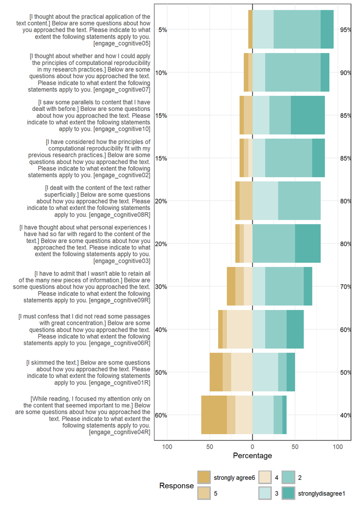

Likert plot of scale engage_cognitive items

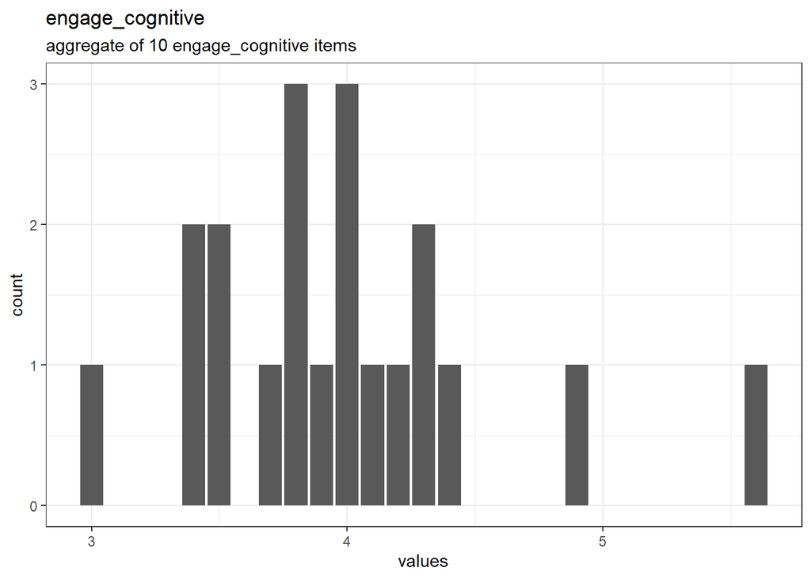

Distribution of scale engage_cognitive

#### Reliability details

###### Reliability

###### 95% Confidence Interval

| lower | estimate | upper |
| --- | --- | --- |
| 0.7588491 | 0.8425245 | 0.9262 |

|  | raw_alpha | std.alpha | G6(smc) | average_r | S/N | ase | mean | sd | median_r |
| --- | --- | --- | --- | --- | --- | --- | --- | --- | --- |
|  | 0.8425245 | 0.8552188 | 0.9415111 | 0.3713449 | 5.906973 | 0.0426916 | 4.18 | 0.8953682 | 0.4488015 |

###### Reliability if an item is dropped:

|  | raw_alpha | std.alpha | G6(smc) | average_r | S/N | alpha se | var.r | med.r |
| --- | --- | --- | --- | --- | --- | --- | --- | --- |
| engage_cognitive01R | 0.8139234 | 0.8325102 | 0.9277435 | 0.3557860 | 4.970512 | 0.0497554 | 0.1257427 | 0.4530947 |
| engage_cognitive02 | 0.8118940 | 0.8247125 | 0.9258351 | 0.3433012 | 4.704912 | 0.0511654 | 0.1067242 | 0.4067150 |
| engage_cognitive03 | 0.8075174 | 0.8238202 | 0.9293968 | 0.3419138 | 4.676020 | 0.0529061 | 0.1156375 | 0.4126016 |
| engage_cognitive04R | 0.8977015 | 0.9015602 | 0.9499119 | 0.5043641 | 9.158492 | 0.0298805 | 0.0296177 | 0.4983785 |
| engage_cognitive05 | 0.8305152 | 0.8431112 | 0.9273210 | 0.3738669 | 5.373941 | 0.0467468 | 0.1029727 | 0.4509149 |
| engage_cognitive06R | 0.8060136 | 0.8251563 | 0.9301909 | 0.3439944 | 4.719395 | 0.0531631 | 0.1219746 | 0.4126016 |
| engage_cognitive07 | 0.8209508 | 0.8332053 | 0.9190759 | 0.3569312 | 4.995393 | 0.0484584 | 0.1145350 | 0.4337624 |
| engage_cognitive08R | 0.8077044 | 0.8249192 | 0.9207678 | 0.3436238 | 4.711648 | 0.0524586 | 0.1166706 | 0.4461337 |
| engage_cognitive09R | 0.8238977 | 0.8397346 | 0.9227540 | 0.3679619 | 5.239648 | 0.0485373 | 0.1172694 | 0.4509149 |
| engage_cognitive10 | 0.8361270 | 0.8474719 | 0.9399201 | 0.3817054 | 5.556167 | 0.0447432 | 0.1123897 | 0.4530947 |

###### Item statistics

|  | n | raw.r | std.r | r.cor | r.drop | mean | sd |
| --- | --- | --- | --- | --- | --- | --- | --- |
| engage_cognitive01R | 20 | 0.7621536 | 0.7439488 | 0.7267871 | 0.6763921 | 3.40 | 1.500877 |
| engage_cognitive02 | 20 | 0.7884878 | 0.8121566 | 0.8104734 | 0.7242125 | 4.55 | 1.276302 |
| engage_cognitive03 | 20 | 0.8132006 | 0.8197361 | 0.8022126 | 0.7479335 | 4.75 | 1.409554 |
| engage_cognitive04R | 20 | -0.0274245 | -0.0677733 | -0.1374081 | -0.2004938 | 2.90 | 1.586124 |
| engage_cognitive05 | 20 | 0.6079766 | 0.6451678 | 0.6289096 | 0.5230566 | 4.70 | 1.080935 |
| engage_cognitive06R | 20 | 0.8220354 | 0.8083693 | 0.7869901 | 0.7573336 | 4.10 | 1.447321 |
| engage_cognitive07 | 20 | 0.7097465 | 0.7376920 | 0.7407092 | 0.6337166 | 4.60 | 1.187656 |
| engage_cognitive08R | 20 | 0.8253330 | 0.8103942 | 0.8106957 | 0.7706269 | 4.05 | 1.276302 |
| engage_cognitive09R | 20 | 0.6886705 | 0.6774284 | 0.6725719 | 0.5804755 | 4.05 | 1.538112 |
| engage_cognitive10 | 20 | 0.5888894 | 0.6023443 | 0.5519143 | 0.4598577 | 4.70 | 1.525227 |

###### Non missing response frequency for each item

|  | 1 | 2 | 3 | 4 | 5 | 6 | miss |
| --- | --- | --- | --- | --- | --- | --- | --- |
| engage_cognitive01R | 0.15 | 0.10 | 0.25 | 0.30 | 0.10 | 0.10 | 0.2857143 |
| engage_cognitive02 | 0.05 | 0.05 | 0.05 | 0.15 | 0.55 | 0.15 | 0.2857143 |
| engage_cognitive03 | 0.05 | 0.05 | 0.10 | 0.00 | 0.50 | 0.30 | 0.2857143 |
| engage_cognitive04R | 0.30 | 0.10 | 0.20 | 0.25 | 0.10 | 0.05 | 0.2857143 |
| engage_cognitive05 | 0.05 | 0.00 | 0.00 | 0.25 | 0.55 | 0.15 | 0.2857143 |
| engage_cognitive06R | 0.05 | 0.05 | 0.30 | 0.15 | 0.25 | 0.20 | 0.2857143 |
| engage_cognitive07 | 0.05 | 0.05 | 0.00 | 0.15 | 0.65 | 0.10 | 0.2857143 |
| engage_cognitive08R | 0.05 | 0.15 | 0.00 | 0.30 | 0.50 | 0.00 | 0.2857143 |
| engage_cognitive09R | 0.10 | 0.10 | 0.10 | 0.15 | 0.45 | 0.10 | 0.2857143 |
| engage_cognitive10 | 0.05 | 0.10 | 0.00 | 0.20 | 0.25 | 0.40 | 0.2857143 |

#### Summary statistics

| name | label | data_type | value_labels | n_missing | complete_rate | min | median | max | mean | sd | hist | format.spss |
| --- | --- | --- | --- | --- | --- | --- | --- | --- | --- | --- | --- | --- |
| engage_cognitive01R | [I skimmed the text.] Below are some questions about how you approached the text. Please indicate to what extent the following statements apply to you. | numeric | 6. stronglydisagree1, 5. 2, 4. 3, 3. 4, 2. 5, 1. strongly agree6 | 8 | 0.7142857 | 1 | 3.5 | 6 | 3.40 | 1.500877 | ▇▇▇▂▂ | F10.0 |
| engage_cognitive02 | [I have considered how the principles of computational reproducibility fit with my previous research practices.] Below are some questions about how you approached the text. Please indicate to what ext… | numeric | 1. stronglydisagree1, 2. 2, 3. 3, 4. 4, 5. 5, 6. strongly agree6 | 8 | 0.7142857 | 1 | 5.0 | 6 | 4.55 | 1.276302 | ▂▁▂▇▂ | F10.0 |
| engage_cognitive03 | [I have thought about what personal experiences I have had so far with regard to the content of the text.] Below are some questions about how you approached the text. Please indicate to what extent th… | numeric | 1. stronglydisagree1, 2. 2, 3. 3, 4. 4, 5. 5, 6. strongly agree6 | 8 | 0.7142857 | 1 | 5.0 | 6 | 4.75 | 1.409554 | ▂▂▁▇▅ | F10.0 |
| engage_cognitive04R | [While reading, I focused my attention only on the content that seemed important to me.] Below are some questions about how you approached the text. Please indicate to what extent the following statem… | numeric | 6. stronglydisagree1, 5. 2, 4. 3, 3. 4, 2. 5, 1. strongly agree6 | 8 | 0.7142857 | 1 | 3.0 | 6 | 2.90 | 1.586124 | ▇▃▅▂▁ | F10.0 |
| engage_cognitive05 | [I thought about the practical application of the text content.] Below are some questions about how you approached the text. Please indicate to what extent the following statements apply to you. | numeric | 1. stronglydisagree1, 2. 2, 3. 3, 4. 4, 5. 5, 6. strongly agree6 | 8 | 0.7142857 | 1 | 5.0 | 6 | 4.70 | 1.080935 | ▁▁▃▇▂ | F10.0 |
| engage_cognitive06R | [I must confess that I did not read some passages with great concentration.] Below are some questions about how you approached the text. Please indicate to what extent the following statements apply t… | numeric | 6. stronglydisagree1, 5. 2, 4. 3, 3. 4, 2. 5, 1. strongly agree6 | 8 | 0.7142857 | 1 | 4.0 | 6 | 4.10 | 1.447321 | ▂▇▃▇▅ | F10.0 |
| engage_cognitive07 | [I thought about whether and how I could apply the principles of computational reproducibility in my research practices.] Below are some questions about how you approached the text. Please indicate to… | numeric | 1. stronglydisagree1, 2. 2, 3. 3, 4. 4, 5. 5, 6. strongly agree6 | 8 | 0.7142857 | 1 | 5.0 | 6 | 4.60 | 1.187656 | ▁▁▂▇▁ | F10.0 |
| engage_cognitive08R | [I dealt with the content of the text rather superficially.] Below are some questions about how you approached the text. Please indicate to what extent the following statements apply to you. | numeric | 6. stronglydisagree1, 5. 2, 4. 3, 3. 4, 2. 5, 1. strongly agree6 | 8 | 0.7142857 | 1 | 4.5 | 5 | 4.05 | 1.276302 | ▁▂▁▅▇ | F10.0 |
| engage_cognitive09R | [I have to admit that I wasn’t able to retain all of the many new pieces of information.] Below are some questions about how you approached the text. Please indicate to what extent the following state… | numeric | 6. stronglydisagree1, 5. 2, 4. 3, 3. 4, 2. 5, 1. strongly agree6 | 8 | 0.7142857 | 1 | 5.0 | 6 | 4.05 | 1.538112 | ▃▂▂▇▂ | F10.0 |
| engage_cognitive10 | [I saw some parallels to content that I have dealt with before.] Below are some questions about how you approached the text. Please indicate to what extent the following statements apply to you. | numeric | 1. stronglydisagree1, 2. 2, 3. 3, 4. 4, 5. 5, 6. strongly agree6 | 8 | 0.7142857 | 1 | 5.0 | 6 | 4.70 | 1.525227 | ▃▁▃▅▇ | F10.0 |

### Scale: resourceInfra

#### Overview

**Reliability**: Cronbach’s α [95% CI] = 0.86 [0.78;0.94].

**Missing**: 7.

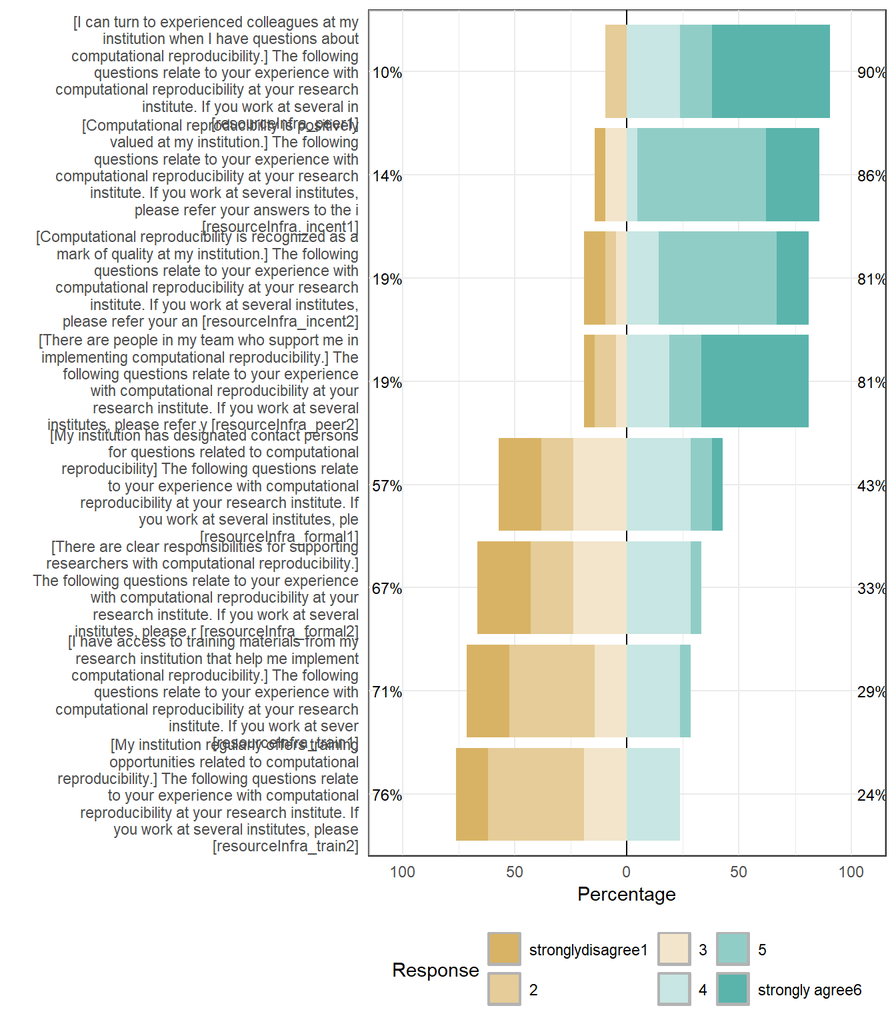

Likert plot of scale resourceInfra items

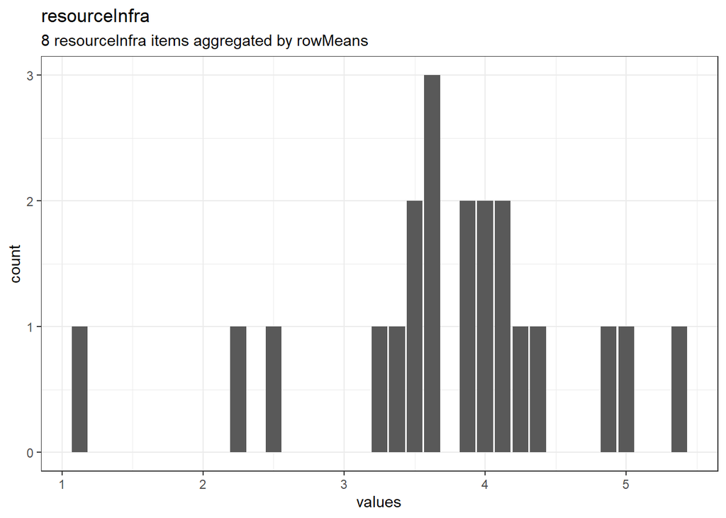

Distribution of scale resourceInfra

#### Reliability details

###### Reliability

###### 95% Confidence Interval

| lower | estimate | upper |
| --- | --- | --- |
| 0.7820978 | 0.8610123 | 0.9399267 |

|  | raw_alpha | std.alpha | G6(smc) | average_r | S/N | ase | mean | sd | median_r |
| --- | --- | --- | --- | --- | --- | --- | --- | --- | --- |
|  | 0.8610123 | 0.8621026 | 0.9455165 | 0.4386661 | 6.251766 | 0.0402625 | 3.72619 | 0.9434139 | 0.4542395 |

###### Reliability if an item is dropped:

|  | raw_alpha | std.alpha | G6(smc) | average_r | S/N | alpha se | var.r | med.r |
| --- | --- | --- | --- | --- | --- | --- | --- | --- |
| resourceInfra_peer1 | 0.8352142 | 0.8371176 | 0.9149482 | 0.4233651 | 5.139397 | 0.0485221 | 0.0373217 | 0.4291523 |
| resourceInfra_peer2 | 0.8310369 | 0.8336664 | 0.9023918 | 0.4172501 | 5.012013 | 0.0501828 | 0.0341452 | 0.4447567 |
| resourceInfra_formal1 | 0.8475490 | 0.8454920 | 0.9270113 | 0.4387499 | 5.472158 | 0.0430036 | 0.0287932 | 0.4447567 |
| resourceInfra_formal2 | 0.8346594 | 0.8363181 | 0.9355851 | 0.4219372 | 5.109411 | 0.0485563 | 0.0387969 | 0.4291523 |
| resourceInfra_train1 | 0.8520653 | 0.8529658 | 0.8964907 | 0.4531736 | 5.801138 | 0.0425800 | 0.0253576 | 0.4682232 |
| resourceInfra_train2 | 0.8537425 | 0.8552214 | 0.9353830 | 0.4576628 | 5.907100 | 0.0434835 | 0.0366016 | 0.5131027 |
| resourceInfra_incent1 | 0.8446637 | 0.8481742 | 0.9133008 | 0.4438484 | 5.586495 | 0.0457439 | 0.0313886 | 0.4637222 |
| resourceInfra_incent2 | 0.8522592 | 0.8530507 | 0.8831077 | 0.4533414 | 5.805067 | 0.0421932 | 0.0187379 | 0.4637222 |

###### Item statistics

|  | n | raw.r | std.r | r.cor | r.drop | mean | sd |
| --- | --- | --- | --- | --- | --- | --- | --- |
| resourceInfra_peer1 | 21 | 0.7723193 | 0.7696319 | 0.7472400 | 0.6863935 | 5.000000 | 1.303840 |
| resourceInfra_peer2 | 21 | 0.8099389 | 0.7921349 | 0.7876619 | 0.7150067 | 4.714286 | 1.585650 |
| resourceInfra_formal1 | 21 | 0.7027916 | 0.7130167 | 0.6924646 | 0.5835643 | 3.095238 | 1.445848 |
| resourceInfra_formal2 | 21 | 0.7761707 | 0.7748865 | 0.7375042 | 0.6940305 | 2.714286 | 1.270545 |
| resourceInfra_train1 | 21 | 0.6436827 | 0.6599381 | 0.6559438 | 0.5343083 | 2.571429 | 1.207122 |
| resourceInfra_train2 | 21 | 0.6177843 | 0.6434180 | 0.5905844 | 0.5220038 | 2.523810 | 1.030488 |
| resourceInfra_incent1 | 21 | 0.7026439 | 0.6942546 | 0.6748735 | 0.6062660 | 4.809524 | 1.209092 |
| resourceInfra_incent2 | 21 | 0.6759421 | 0.6593207 | 0.6626939 | 0.5471819 | 4.380952 | 1.465476 |

###### Non missing response frequency for each item

|  | 1 | 2 | 3 | 4 | 5 | 6 | miss |
| --- | --- | --- | --- | --- | --- | --- | --- |
| resourceInfra_peer1 | 0.0000000 | 0.0952381 | 0.0000000 | 0.2380952 | 0.1428571 | 0.5238095 | 0.25 |
| resourceInfra_peer2 | 0.0476190 | 0.0952381 | 0.0476190 | 0.1904762 | 0.1428571 | 0.4761905 | 0.25 |
| resourceInfra_formal1 | 0.1904762 | 0.1428571 | 0.2380952 | 0.2857143 | 0.0952381 | 0.0476190 | 0.25 |
| resourceInfra_formal2 | 0.2380952 | 0.1904762 | 0.2380952 | 0.2857143 | 0.0476190 | 0.0000000 | 0.25 |
| resourceInfra_train1 | 0.1904762 | 0.3809524 | 0.1428571 | 0.2380952 | 0.0476190 | 0.0000000 | 0.25 |
| resourceInfra_train2 | 0.1428571 | 0.4285714 | 0.1904762 | 0.2380952 | 0.0000000 | 0.0000000 | 0.25 |
| resourceInfra_incent1 | 0.0476190 | 0.0000000 | 0.0952381 | 0.0476190 | 0.5714286 | 0.2380952 | 0.25 |
| resourceInfra_incent2 | 0.0952381 | 0.0476190 | 0.0476190 | 0.1428571 | 0.5238095 | 0.1428571 | 0.25 |

#### Summary statistics

| name | label | data_type | value_labels | n_missing | complete_rate | min | median | max | mean | sd | hist | format.spss |
| --- | --- | --- | --- | --- | --- | --- | --- | --- | --- | --- | --- | --- |
| resourceInfra_peer1 | [I can turn to experienced colleagues at my institution when I have questions about computational reproducibility.] The following questions relate to your experience with computational reproducibility… | numeric | 1. stronglydisagree1, 2. 2, 3. 3, 4. 4, 5. 5, 6. strongly agree6 | 7 | 0.75 | 2 | 6 | 6 | 5.000000 | 1.303840 | ▂▁▃▂▇ | F10.0 |
| resourceInfra_peer2 | [There are people in my team who support me in implementing computational reproducibility.] The following questions relate to your experience with computational reproducibility at your research instit… | numeric | 1. stronglydisagree1, 2. 2, 3. 3, 4. 4, 5. 5, 6. strongly agree6 | 7 | 0.75 | 1 | 5 | 6 | 4.714286 | 1.585650 | ▂▁▃▂▇ | F10.0 |
| resourceInfra_formal1 | [My institution has designated contact persons for questions related to computational reproducibility] The following questions relate to your experience with computational reproducibility at your rese… | numeric | 1. stronglydisagree1, 2. 2, 3. 3, 4. 4, 5. 5, 6. strongly agree6 | 7 | 0.75 | 1 | 3 | 6 | 3.095238 | 1.445848 | ▇▆▇▂▁ | F10.0 |
| resourceInfra_formal2 | [There are clear responsibilities for supporting researchers with computational reproducibility.] The following questions relate to your experience with computational reproducibility at your research … | numeric | 1. stronglydisagree1, 2. 2, 3. 3, 4. 4, 5. 5, 6. strongly agree6 | 7 | 0.75 | 1 | 3 | 5 | 2.714286 | 1.270545 | ▇▅▇▇▁ | F10.0 |
| resourceInfra_train1 | [I have access to training materials from my research institution that help me implement computational reproducibility.] The following questions relate to your experience with computational reproducib… | numeric | 1. stronglydisagree1, 2. 2, 3. 3, 4. 4, 5. 5, 6. strongly agree6 | 7 | 0.75 | 1 | 2 | 5 | 2.571429 | 1.207122 | ▃▇▃▅▁ | F10.0 |
| resourceInfra_train2 | [My institution regularly offers training opportunities related to computational reproducibility.] The following questions relate to your experience with computational reproducibility at your research… | numeric | 1. stronglydisagree1, 2. 2, 3. 3, 4. 4, 5. 5, 6. strongly agree6 | 7 | 0.75 | 1 | 2 | 4 | 2.523810 | 1.030488 | ▂▇▁▃▅ | F10.0 |
| resourceInfra_incent1 | [Computational reproducibility is positively valued at my institution.] The following questions relate to your experience with computational reproducibility at your research institute. If you work at … | numeric | 1. stronglydisagree1, 2. 2, 3. 3, 4. 4, 5. 5, 6. strongly agree6 | 7 | 0.75 | 1 | 5 | 6 | 4.809524 | 1.209092 | ▁▁▁▇▃ | F10.0 |
| resourceInfra_incent2 | [Computational reproducibility is recognized as a mark of quality at my institution.] The following questions relate to your experience with computational reproducibility at your research institute. I… | numeric | 1. stronglydisagree1, 2. 2, 3. 3, 4. 4, 5. 5, 6. strongly agree6 | 7 | 0.75 | 1 | 5 | 6 | 4.380952 | 1.465476 | ▂▁▂▇▂ | F10.0 |

## Missingness report

| description | lastpage | consentInfo_yes | resourcePerson_va4 | resourcePerson_eos6 | resourcePerson_eos1 | resourcePerson_eos2 | resourcePerson_va3 | resourcePerson_eos3 | resourcePerson_eos5 | resourcePerson_va1 | resourcePerson_va2 | resourcePerson_eos4R | resourceInfra_peer1 | resourceInfra_peer2 | resourceInfra_formal1 | resourceInfra_formal2 | resourceInfra_train1 | resourceInfra_train2 | resourceInfra_incent1 | resourceInfra_incent2 | experience | resourcePerson_va | resourcePerson_eos | resourceInfra | implicates_self1 | implicates_self2 | implicates_self3 | implicates_self4 | challenge_1 | … |
| --- | --- | --- | --- | --- | --- | --- | --- | --- | --- | --- | --- | --- | --- | --- | --- | --- | --- | --- | --- | --- | --- | --- | --- | --- | --- | --- | --- | --- | --- | --- |
| Missing values per variable | 3 | 3 | 7 | 7 | 7 | 7 | 7 | 7 | 7 | 7 | 7 | 7 | 7 | 7 | 7 | 7 | 7 | 7 | 7 | 7 | 7 | 7 | 7 | 7 | 8 | 8 | 8 | 8 | 8 | … |
| Missing values in 0 variables | 1 | 1 | 1 | 1 | 1 | 1 | 1 | 1 | 1 | 1 | 1 | 1 | 1 | 1 | 1 | 1 | 1 | 1 | 1 | 1 | 1 | 1 | 1 | 1 | 1 | 1 | 1 | 1 | 1 | … |
| Missing values in 1 variables | 1 | 1 | 1 | 1 | 1 | 1 | 1 | 1 | 1 | 1 | 1 | 1 | 1 | 1 | 1 | 1 | 1 | 1 | 1 | 1 | 1 | 1 | 1 | 1 | 1 | 1 | 1 | 1 | 1 | … |
| Missing values in 51 variables | 1 | 1 | 0 | 0 | 0 | 0 | 0 | 0 | 0 | 0 | 0 | 0 | 0 | 0 | 0 | 0 | 0 | 0 | 0 | 0 | 0 | 0 | 0 | 0 | 0 | 0 | 0 | 0 | 0 | … |
| Missing values in 53 variables | 0 | 0 | 0 | 0 | 0 | 0 | 0 | 0 | 0 | 0 | 0 | 0 | 0 | 0 | 0 | 0 | 0 | 0 | 0 | 0 | 0 | 0 | 0 | 0 | 0 | 0 | 0 | 0 | 0 | … |
| Missing values in 1 variables | 1 | 1 | 1 | 1 | 1 | 1 | 1 | 1 | 1 | 1 | 1 | 1 | 1 | 1 | 1 | 1 | 1 | 1 | 1 | 1 | 1 | 1 | 1 | 1 | 1 | 1 | 1 | 1 | 1 | … |
| Missing values in 2 variables | 1 | 1 | 1 | 1 | 1 | 1 | 1 | 1 | 1 | 1 | 1 | 1 | 1 | 1 | 1 | 1 | 1 | 1 | 1 | 1 | 1 | 1 | 1 | 1 | 1 | 1 | 1 | 1 | 1 | … |
| Missing values in 29 variables | 1 | 1 | 1 | 1 | 1 | 1 | 1 | 1 | 1 | 1 | 1 | 1 | 1 | 1 | 1 | 1 | 1 | 1 | 1 | 1 | 1 | 1 | 1 | 1 | 0 | 0 | 0 | 0 | 0 | … |

## Codebook table

| name | label | data_type | value_labels | scale_item_names | n_missing | complete_rate | n_unique | empty | min | median | max | mean | sd | whitespace | hist | format.spss |
| --- | --- | --- | --- | --- | --- | --- | --- | --- | --- | --- | --- | --- | --- | --- | --- | --- |
| id | Response ID | numeric | NA | NA | 0 | 1.0000000 | NA | NA | 5.0e+00 | 1.8e+01 | 3.2e+01 | 1.850000e+01 | 8.225975e+00 | NA | ▇▇▇▇▇ | F2.0 |
| submitdate | Date submitted | POSIXct | NA | NA | 12 | 0.5714286 | 1 | NA | 1980-01-01 | 1980-01-01 | 1980-01-01 | NA | NA | NA | NA | DATETIME20 |
| lastpage | Last page | numeric | NA | NA | 3 | 0.8928571 | NA | NA | 2.0e+00 | 1.1e+01 | 1.1e+01 | 9.000000e+00 | 3.391165e+00 | NA | ▂▁▁▂▇ | F2.0 |
| startlanguage | Start language | character | NA | NA | 0 | 1.0000000 | 1 | 0 | 2 | NA | 2 | NA | NA | 0 | NA | A2 |
| seed | Seed | numeric | NA | NA | 0 | 1.0000000 | NA | NA | 5.3e+06 | 1.2e+09 | 2.1e+09 | 1.180732e+09 | 6.469870e+08 | NA | ▃▅▆▅▇ | F10.0 |
| datenschutz | What happens to your data? Information on data protection We work in accordance with the provisions of the European General Data Protection Regulation.The following data will be collected as part of t… | character | NA | NA | 0 | 1.0000000 | 1 | 28 | 0 | NA | 0 | NA | NA | 0 | NA | A1 |
| consentInfo_yes | [I acknowledge that I have been informed about the voluntariness of my participation and the details of data protection, and I consent to the processing of my data as described.] | numeric | 1. Yes, 0. Not selected | NA | 3 | 0.8928571 | NA | NA | 1.0e+00 | 1.0e+00 | 1.0e+00 | 1.000000e+00 | 0.000000e+00 | NA | ▁▁▇▁▁ | F10.0 |
| introScenario | On the next page you will find a fictitious scenario that could be taken from the practical experience of a researcher. Please take a moment to put yourself in this situation and answer the following … | character | NA | NA | 0 | 1.0000000 | 1 | 28 | 0 | NA | 0 | NA | NA | 0 | NA | A1 |
| vignetteVersionA | Consider the following scenario Imagine you are applying for a grant from a research funder to conduct a study on the relationship between students’ self-regulated learning strategies and their academ… | character | NA | NA | 0 | 1.0000000 | 1 | 28 | 0 | NA | 0 | NA | NA | 0 | NA | A1 |
| resourcePerson_va4 | [I cannot spend as much time doing the other things that I would like when I focus on ensuring computational reproducibility. ] How do you feel about the idea of making your research reproducible, as … | numeric | 1. stronglydisagree1, 2. 2, 3. 3, 4. 4, 5. 5, 6. strongly agree6 | NA | 7 | 0.7500000 | NA | NA | 1.0e+00 | 2.0e+00 | 6.0e+00 | 2.809524e+00 | 1.470342e+00 | NA | ▇▁▅▁▁ | F10.0 |
| resourcePerson_eos6 | [The more effort I invest in understanding computational reproducibility methods, the better I perform. ] How do you feel about the idea of making your research reproducible, as described in this scen… | numeric | 1. stronglydisagree1, 2. 2, 3. 3, 4. 4, 5. 5, 6. strongly agree6 | NA | 7 | 0.7500000 | NA | NA | 2.0e+00 | 5.0e+00 | 6.0e+00 | 4.523809e+00 | 1.209092e+00 | NA | ▁▅▅▇▆ | F10.0 |
| resourcePerson_eos1 | [When I take the time to thoroughly learn a new concept in computational reproducibility, I understand it well.] How do you feel about the idea of making your research reproducible, as described in th… | numeric | 1. stronglydisagree1, 2. 2, 3. 3, 4. 4, 5. 5, 6. strongly agree6 | NA | 7 | 0.7500000 | NA | NA | 3.0e+00 | 5.0e+00 | 6.0e+00 | 4.714286e+00 | 9.561829e-01 | NA | ▂▃▁▇▃ | F10.0 |
| resourcePerson_eos2 | [If I put in significant effort to avoid mistakes in computational reproducibility tasks, I am successful in doing so. ] How do you feel about the idea of making your research reproducible, as describ… | numeric | 1. stronglydisagree1, 2. 2, 3. 3, 4. 4, 5. 5, 6. strongly agree6 | NA | 7 | 0.7500000 | NA | NA | 2.0e+00 | 5.0e+00 | 6.0e+00 | 4.666667e+00 | 1.064581e+00 | NA | ▁▂▃▇▃ | F10.0 |
| resourcePerson_va3 | [Focusing on computational reproducibility causes me to miss out on too many other things I care about. ] How do you feel about the idea of making your research reproducible, as described in this scen… | numeric | 1. stronglydisagree1, 2. 2, 3. 3, 4. 4, 5. 5, 6. strongly agree6 | NA | 7 | 0.7500000 | NA | NA | 1.0e+00 | 2.0e+00 | 5.0e+00 | 2.523810e+00 | 1.209092e+00 | NA | ▃▇▅▂▂ | F10.0 |
| resourcePerson_eos3 | [When I put effort into being accurate in computational reproducibility tasks, I succeed in avoiding errors. ] How do you feel about the idea of making your research reproducible, as described in this… | numeric | 1. stronglydisagree1, 2. 2, 3. 3, 4. 4, 5. 5, 6. strongly agree6 | NA | 7 | 0.7500000 | NA | NA | 3.0e+00 | 5.0e+00 | 6.0e+00 | 4.761905e+00 | 9.952267e-01 | NA | ▂▃▁▇▅ | F10.0 |
| resourcePerson_eos5 | [When I try hard, I usually achieve computationally reproducible results.] How do you feel about the idea of making your research reproducible, as described in this scenario? | numeric | 1. stronglydisagree1, 2. 2, 3. 3, 4. 4, 5. 5, 6. strongly agree6 | NA | 7 | 0.7500000 | NA | NA | 1.0e+00 | 5.0e+00 | 6.0e+00 | 4.952381e+00 | 1.160870e+00 | NA | ▁▁▃▇▆ | F10.0 |
| resourcePerson_va1 | [I have to sacrifice too much to ensure computational reproducibility in my work. ] How do you feel about the idea of making your research reproducible, as described in this scenario? | numeric | 1. stronglydisagree1, 2. 2, 3. 3, 4. 4, 5. 5, 6. strongly agree6 | NA | 7 | 0.7500000 | NA | NA | 1.0e+00 | 2.0e+00 | 6.0e+00 | 2.619048e+00 | 1.430950e+00 | NA | ▇▁▂▁▁ | F10.0 |
| resourcePerson_va2 | [Making results computationally reproducible requires me to give up too many other activities I value. ] How do you feel about the idea of making your research reproducible, as described in this scena… | numeric | 1. stronglydisagree1, 2. 2, 3. 3, 4. 4, 5. 5, 6. strongly agree6 | NA | 7 | 0.7500000 | NA | NA | 1.0e+00 | 2.0e+00 | 6.0e+00 | 2.714286e+00 | 1.521278e+00 | NA | ▇▂▁▁▁ | F10.0 |
| resourcePerson_eos4R | [For me, putting a lot of effort into computational reproducibility doesn’t make sense because I don’t think it improves my outcomes.] How do you feel about the idea of making your research reproducib… | numeric | 6. stronglydisagree1, 5. 2, 4. 3, 3. 4, 2. 5, 1. strongly agree6 | NA | 7 | 0.7500000 | NA | NA | 1.0e+00 | 5.0e+00 | 6.0e+00 | 5.047619e+00 | 1.359271e+00 | NA | ▂▁▂▆▇ | F10.0 |
| resourceInfra_peer1 | [I can turn to experienced colleagues at my institution when I have questions about computational reproducibility.] The following questions relate to your experience with computational reproducibility… | numeric | 1. stronglydisagree1, 2. 2, 3. 3, 4. 4, 5. 5, 6. strongly agree6 | NA | 7 | 0.7500000 | NA | NA | 2.0e+00 | 6.0e+00 | 6.0e+00 | 5.000000e+00 | 1.303840e+00 | NA | ▂▁▃▂▇ | F10.0 |
| resourceInfra_peer2 | [There are people in my team who support me in implementing computational reproducibility.] The following questions relate to your experience with computational reproducibility at your research instit… | numeric | 1. stronglydisagree1, 2. 2, 3. 3, 4. 4, 5. 5, 6. strongly agree6 | NA | 7 | 0.7500000 | NA | NA | 1.0e+00 | 5.0e+00 | 6.0e+00 | 4.714286e+00 | 1.585650e+00 | NA | ▂▁▃▂▇ | F10.0 |
| resourceInfra_formal1 | [My institution has designated contact persons for questions related to computational reproducibility] The following questions relate to your experience with computational reproducibility at your rese… | numeric | 1. stronglydisagree1, 2. 2, 3. 3, 4. 4, 5. 5, 6. strongly agree6 | NA | 7 | 0.7500000 | NA | NA | 1.0e+00 | 3.0e+00 | 6.0e+00 | 3.095238e+00 | 1.445848e+00 | NA | ▇▆▇▂▁ | F10.0 |
| resourceInfra_formal2 | [There are clear responsibilities for supporting researchers with computational reproducibility.] The following questions relate to your experience with computational reproducibility at your research … | numeric | 1. stronglydisagree1, 2. 2, 3. 3, 4. 4, 5. 5, 6. strongly agree6 | NA | 7 | 0.7500000 | NA | NA | 1.0e+00 | 3.0e+00 | 5.0e+00 | 2.714286e+00 | 1.270545e+00 | NA | ▇▅▇▇▁ | F10.0 |
| resourceInfra_train1 | [I have access to training materials from my research institution that help me implement computational reproducibility.] The following questions relate to your experience with computational reproducib… | numeric | 1. stronglydisagree1, 2. 2, 3. 3, 4. 4, 5. 5, 6. strongly agree6 | NA | 7 | 0.7500000 | NA | NA | 1.0e+00 | 2.0e+00 | 5.0e+00 | 2.571429e+00 | 1.207122e+00 | NA | ▃▇▃▅▁ | F10.0 |
| resourceInfra_train2 | [My institution regularly offers training opportunities related to computational reproducibility.] The following questions relate to your experience with computational reproducibility at your research… | numeric | 1. stronglydisagree1, 2. 2, 3. 3, 4. 4, 5. 5, 6. strongly agree6 | NA | 7 | 0.7500000 | NA | NA | 1.0e+00 | 2.0e+00 | 4.0e+00 | 2.523810e+00 | 1.030488e+00 | NA | ▂▇▁▃▅ | F10.0 |
| resourceInfra_incent1 | [Computational reproducibility is positively valued at my institution.] The following questions relate to your experience with computational reproducibility at your research institute. If you work at … | numeric | 1. stronglydisagree1, 2. 2, 3. 3, 4. 4, 5. 5, 6. strongly agree6 | NA | 7 | 0.7500000 | NA | NA | 1.0e+00 | 5.0e+00 | 6.0e+00 | 4.809524e+00 | 1.209092e+00 | NA | ▁▁▁▇▃ | F10.0 |
| resourceInfra_incent2 | [Computational reproducibility is recognized as a mark of quality at my institution.] The following questions relate to your experience with computational reproducibility at your research institute. I… | numeric | 1. stronglydisagree1, 2. 2, 3. 3, 4. 4, 5. 5, 6. strongly agree6 | NA | 7 | 0.7500000 | NA | NA | 1.0e+00 | 5.0e+00 | 6.0e+00 | 4.380952e+00 | 1.465476e+00 | NA | ▂▁▂▇▂ | F10.0 |
| experience | How often have you documented and provided the data as well as data analysis in such a way that other researchers can understand and follow the steps to obtain exactly the same results as you? | numeric | NA | NA | 7 | 0.7500000 | NA | NA | 0.0e+00 | 1.0e+00 | 6.0e+00 | 1.476190e+00 | 1.631535e+00 | NA | ▇▂▂▁▁ | F10.0 |
| introText | In the following section, after a set of preliminary questions, you will have the opportunity to read a short informational text on the topic of computational reproducibility, including links to relev… | character | NA | NA | 0 | 1.0000000 | 1 | 28 | 0 | NA | 0 | NA | NA | 0 | NA | A1 |
| headerExpectations | What are your expectations with regard to the informational text? The text will be shown on the next page. | character | NA | NA | 0 | 1.0000000 | 1 | 28 | 0 | NA | 0 | NA | NA | 0 | NA | A1 |
| implicates_self1 | [The content of the topic is probably relevant to me.] | numeric | 1. stronglydisagree1, 2. 2, 3. 3, 4. 4, 5. 5, 6. strongly agree6 | NA | 8 | 0.7142857 | NA | NA | 2.0e+00 | 5.0e+00 | 6.0e+00 | 4.950000e+00 | 1.050063e+00 | NA | ▁▁▂▇▅ | F10.0 |
| implicates_self2 | [The topic of computational reproducibility is very important in my data analysis practices.] | numeric | 1. stronglydisagree1, 2. 2, 3. 3, 4. 4, 5. 5, 6. strongly agree6 | NA | 8 | 0.7142857 | NA | NA | 3.0e+00 | 5.0e+00 | 6.0e+00 | 4.850000e+00 | 1.136708e+00 | NA | ▅▂▁▇▇ | F10.0 |
| implicates_self3 | [Computational reproducibility is important for my research.] | numeric | 1. stronglydisagree1, 2. 2, 3. 3, 4. 4, 5. 5, 6. strongly agree6 | NA | 8 | 0.7142857 | NA | NA | 3.0e+00 | 5.0e+00 | 6.0e+00 | 4.700000e+00 | 1.128576e+00 | NA | ▅▅▁▇▇ | F10.0 |
| implicates_self4 | [It is important for me to be familiar with the topic of computational reproducibility.] | numeric | 1. stronglydisagree1, 2. 2, 3. 3, 4. 4, 5. 5, 6. strongly agree6 | NA | 8 | 0.7142857 | NA | NA | 2.0e+00 | 5.0e+00 | 6.0e+00 | 4.950000e+00 | 1.190975e+00 | NA | ▁▂▂▇▇ | F10.0 |
| challenge_1 | [I would like to learn something new about computational reproducibility.] | numeric | 1. stronglydisagree1, 2. 2, 3. 3, 4. 4, 5. 5, 6. strongly agree6 | NA | 8 | 0.7142857 | NA | NA | 2.0e+00 | 5.0e+00 | 6.0e+00 | 5.000000e+00 | 1.213954e+00 | NA | ▁▂▂▅▇ | F10.0 |
| challenge_2 | [I am looking forward to dealing with challenging content.] | numeric | 1. stronglydisagree1, 2. 2, 3. 3, 4. 4, 5. 5, 6. strongly agree6 | NA | 8 | 0.7142857 | NA | NA | 2.0e+00 | 4.0e+00 | 6.0e+00 | 4.200000e+00 | 1.151658e+00 | NA | ▂▃▇▇▂ | F10.0 |
| challenge_3 | [The text is an exciting challenge for me.] | numeric | 1. stronglydisagree1, 2. 2, 3. 3, 4. 4, 5. 5, 6. strongly agree6 | NA | 8 | 0.7142857 | NA | NA | 1.0e+00 | 4.0e+00 | 6.0e+00 | 3.600000e+00 | 1.429023e+00 | NA | ▅▇▇▃▂ | F10.0 |
| challenge_4 | [I am curious to see what I will learn from the text.] | numeric | 1. stronglydisagree1, 2. 2, 3. 3, 4. 4, 5. 5, 6. strongly agree6 | NA | 8 | 0.7142857 | NA | NA | 3.0e+00 | 5.0e+00 | 6.0e+00 | 4.750000e+00 | 1.164158e+00 | NA | ▅▅▁▆▇ | F10.0 |
| threat_1 | [I’m worried about whether I will understand the content of the text.] | numeric | 1. stronglydisagree1, 2. 2, 3. 3, 4. 4, 5. 5, 6. strongly agree6 | NA | 8 | 0.7142857 | NA | NA | 1.0e+00 | 3.0e+00 | 6.0e+00 | 3.100000e+00 | 1.518309e+00 | NA | ▇▂▅▂▁ | F10.0 |
| threat_2 | [I am worried that reading the text will reveal my knowledge gaps.] | numeric | 1. stronglydisagree1, 2. 2, 3. 3, 4. 4, 5. 5, 6. strongly agree6 | NA | 8 | 0.7142857 | NA | NA | 1.0e+00 | 2.5e+00 | 6.0e+00 | 2.800000e+00 | 1.704483e+00 | NA | ▇▃▂▂▂ | F10.0 |
| threat_3 | [I believe that the text will cause me difficulties.] | numeric | 1. stronglydisagree1, 2. 2, 3. 3, 4. 4, 5. 5, 6. strongly agree6 | NA | 8 | 0.7142857 | NA | NA | 1.0e+00 | 3.0e+00 | 6.0e+00 | 3.000000e+00 | 1.337712e+00 | NA | ▇▇▆▁▁ | F10.0 |
| infotext | Solutions to promote reproducibility Below you’ll find information on how open file formats and software, Input-Output-Documents (“Notebooks”) and version managemend and containerization promote compu… | character | NA | NA | 0 | 1.0000000 | 1 | 28 | 0 | NA | 0 | NA | NA | 0 | NA | A1 |
| engage_cognitive01R | [I skimmed the text.] Below are some questions about how you approached the text. Please indicate to what extent the following statements apply to you. | numeric | 6. stronglydisagree1, 5. 2, 4. 3, 3. 4, 2. 5, 1. strongly agree6 | NA | 8 | 0.7142857 | NA | NA | 1.0e+00 | 3.5e+00 | 6.0e+00 | 3.400000e+00 | 1.500877e+00 | NA | ▇▇▇▂▂ | F10.0 |
| engage_cognitive02 | [I have considered how the principles of computational reproducibility fit with my previous research practices.] Below are some questions about how you approached the text. Please indicate to what ext… | numeric | 1. stronglydisagree1, 2. 2, 3. 3, 4. 4, 5. 5, 6. strongly agree6 | NA | 8 | 0.7142857 | NA | NA | 1.0e+00 | 5.0e+00 | 6.0e+00 | 4.550000e+00 | 1.276302e+00 | NA | ▂▁▂▇▂ | F10.0 |
| engage_cognitive03 | [I have thought about what personal experiences I have had so far with regard to the content of the text.] Below are some questions about how you approached the text. Please indicate to what extent th… | numeric | 1. stronglydisagree1, 2. 2, 3. 3, 4. 4, 5. 5, 6. strongly agree6 | NA | 8 | 0.7142857 | NA | NA | 1.0e+00 | 5.0e+00 | 6.0e+00 | 4.750000e+00 | 1.409554e+00 | NA | ▂▂▁▇▅ | F10.0 |
| engage_cognitive04R | [While reading, I focused my attention only on the content that seemed important to me.] Below are some questions about how you approached the text. Please indicate to what extent the following statem… | numeric | 6. stronglydisagree1, 5. 2, 4. 3, 3. 4, 2. 5, 1. strongly agree6 | NA | 8 | 0.7142857 | NA | NA | 1.0e+00 | 3.0e+00 | 6.0e+00 | 2.900000e+00 | 1.586124e+00 | NA | ▇▃▅▂▁ | F10.0 |
| engage_cognitive05 | [I thought about the practical application of the text content.] Below are some questions about how you approached the text. Please indicate to what extent the following statements apply to you. | numeric | 1. stronglydisagree1, 2. 2, 3. 3, 4. 4, 5. 5, 6. strongly agree6 | NA | 8 | 0.7142857 | NA | NA | 1.0e+00 | 5.0e+00 | 6.0e+00 | 4.700000e+00 | 1.080935e+00 | NA | ▁▁▃▇▂ | F10.0 |
| engage_cognitive06R | [I must confess that I did not read some passages with great concentration.] Below are some questions about how you approached the text. Please indicate to what extent the following statements apply t… | numeric | 6. stronglydisagree1, 5. 2, 4. 3, 3. 4, 2. 5, 1. strongly agree6 | NA | 8 | 0.7142857 | NA | NA | 1.0e+00 | 4.0e+00 | 6.0e+00 | 4.100000e+00 | 1.447321e+00 | NA | ▂▇▃▇▅ | F10.0 |
| engage_cognitive07 | [I thought about whether and how I could apply the principles of computational reproducibility in my research practices.] Below are some questions about how you approached the text. Please indicate to… | numeric | 1. stronglydisagree1, 2. 2, 3. 3, 4. 4, 5. 5, 6. strongly agree6 | NA | 8 | 0.7142857 | NA | NA | 1.0e+00 | 5.0e+00 | 6.0e+00 | 4.600000e+00 | 1.187656e+00 | NA | ▁▁▂▇▁ | F10.0 |
| engage_cognitive08R | [I dealt with the content of the text rather superficially.] Below are some questions about how you approached the text. Please indicate to what extent the following statements apply to you. | numeric | 6. stronglydisagree1, 5. 2, 4. 3, 3. 4, 2. 5, 1. strongly agree6 | NA | 8 | 0.7142857 | NA | NA | 1.0e+00 | 4.5e+00 | 5.0e+00 | 4.050000e+00 | 1.276302e+00 | NA | ▁▂▁▅▇ | F10.0 |
| engage_cognitive09R | [I have to admit that I wasn’t able to retain all of the many new pieces of information.] Below are some questions about how you approached the text. Please indicate to what extent the following state… | numeric | 6. stronglydisagree1, 5. 2, 4. 3, 3. 4, 2. 5, 1. strongly agree6 | NA | 8 | 0.7142857 | NA | NA | 1.0e+00 | 5.0e+00 | 6.0e+00 | 4.050000e+00 | 1.538112e+00 | NA | ▃▂▂▇▂ | F10.0 |
| engage_cognitive10 | [I saw some parallels to content that I have dealt with before.] Below are some questions about how you approached the text. Please indicate to what extent the following statements apply to you. | numeric | 1. stronglydisagree1, 2. 2, 3. 3, 4. 4, 5. 5, 6. strongly agree6 | NA | 8 | 0.7142857 | NA | NA | 1.0e+00 | 5.0e+00 | 6.0e+00 | 4.700000e+00 | 1.525227e+00 | NA | ▃▁▃▅▇ | F10.0 |
| gender | At the end, we would like to ask you for some demographic information. Gender: How do you identify? | character | AO01. male, AO02. female, AO03. non-binary | NA | 0 | 1.0000000 | 3 | 8 | 0 | NA | 4 | NA | NA | 0 | NA | A28 |
| age | What is your age? | numeric | NA | NA | 10 | 0.6428571 | NA | NA | 2.5e+01 | 3.0e+01 | 3.8e+01 | 3.138889e+01 | 3.806170e+00 | NA | ▁▇▁▃▂ | F10.0 |
| country | In which country is your primary workplace located? | character | NA | NA | 0 | 1.0000000 | 4 | 8 | 0 | NA | 11 | NA | NA | 0 | NA | A11 |
| careerStage | What is your current career stage in academia? | numeric | 1. Doctoral/PhD student, 2. Postdoctoral researcher, 3. Junior faculty / Early career researcher (e.g., Assistant Professor, Junior Lecturer), 4. Mid-career faculty (e.g., Associate Professor, Senior … | NA | 9 | 0.6785714 | NA | NA | 1.0e+00 | 1.0e+00 | 2.0e+00 | 1.368421e+00 | 4.955946e-01 | NA | ▇▁▁▁▅ | F10.0 |
| engageBehavioral | Would you like to download the information text and further practical suggestions on how you can improve the computational reproducibility of your data analyses? Download will be provided on the next … | numeric | 1. Yes, 0. No | NA | 8 | 0.7142857 | NA | NA | 0.0e+00 | 1.0e+00 | 1.0e+00 | 8.500000e-01 | 3.663475e-01 | NA | ▂▁▁▁▇ | F10.0 |
| downloadText | Download the informational text. | character | NA | NA | 0 | 1.0000000 | 1 | 28 | 0 | NA | 0 | NA | NA | 0 | NA | A1 |
| donation | Donation As announced in the invitation email, we will make a donation of … € for each completed survey. You can choose from the following options where this donation should go: | character | AO01. Platzhalter 1, AO02. Platzhalter 2, AO03. Platzhalter 3, AO04. Platzhalter 4 | NA | 0 | 1.0000000 | 4 | 12 | 0 | NA | 4 | NA | NA | 0 | NA | A28 |
| resourcePerson_va | aggregate of 4 resourcePerson_va items | numeric | NA | resourcePerson_va4, resourcePerson_va3, resourcePerson_va1, resourcePerson_va2 | 7 | 0.7500000 | NA | NA | 1.0e+00 | 2.5e+00 | 5.8e+00 | 2.666667e+00 | 1.314185e+00 | NA | ▆▇▃▁▂ | NA |
| resourcePerson_eos | aggregate of 6 resourcePerson_eos items | numeric | NA | resourcePerson_eos6, resourcePerson_eos1, resourcePerson_eos2, resourcePerson_eos3, resourcePerson_eos5, resourcePerson_eos4R | 7 | 0.7500000 | NA | NA | 2.3e+00 | 4.2e+00 | 5.7e+00 | 4.261905e+00 | 7.313827e-01 | NA | ▂▂▇▅▂ | NA |
| implicates_self | aggregate of 4 implicates_self items | numeric | NA | implicates_self1, implicates_self2, implicates_self3, implicates_self4 | 8 | 0.7142857 | NA | NA | 3.0e+00 | 5.0e+00 | 6.0e+00 | 4.862500e+00 | 9.613416e-01 | NA | ▃▁▆▅▇ | NA |
| challenge | aggregate of 4 challenge items | numeric | NA | challenge_1, challenge_2, challenge_3, challenge_4 | 8 | 0.7142857 | NA | NA | 2.8e+00 | 4.5e+00 | 6.0e+00 | 4.387500e+00 | 1.011366e+00 | NA | ▆▅▇▆▆ | NA |
| threat | aggregate of 3 threat items | numeric | NA | threat_1, threat_2, threat_3 | 8 | 0.7142857 | NA | NA | 1.0e+00 | 2.8e+00 | 6.0e+00 | 2.966667e+00 | 1.438404e+00 | NA | ▇▃▅▃▁ | NA |
| engage_cognitive | aggregate of 10 engage_cognitive items | numeric | NA | engage_cognitive01R, engage_cognitive02, engage_cognitive03, engage_cognitive04R, engage_cognitive05, engage_cognitive06R, engage_cognitive07, engage_cognitive08R, engage_cognitive09R, engage_cognitiv… | 8 | 0.7142857 | NA | NA | 3.0e+00 | 4.0e+00 | 5.6e+00 | 3.980000e+00 | 5.708719e-01 | NA | ▅▇▅▁▁ | NA |
| resourceInfra | 8 resourceInfra items aggregated by rowMeans | numeric | NA | resourceInfra_peer1, resourceInfra_peer2, resourceInfra_formal1, resourceInfra_formal2, resourceInfra_train1, resourceInfra_train2, resourceInfra_incent1, resourceInfra_incent2 | 7 | 0.7500000 | NA | NA | 1.1e+00 | 3.9e+00 | 5.4e+00 | 3.726190e+00 | 9.434139e-01 | NA | ▁▂▇▇▃ | NA |

**JSON-LD metadata**

The following JSON-LD can be found by search engines, if you share this codebook publicly on the web.

```json
{
  "name": "codebook_data",
  "datePublished": "2025-09-16",
  "description": "The dataset has N=28 rows and 66 columns.\n14 rows have no missing values on any column.\n\n\n## Table of variables\nThis table contains variable names, labels, and number of missing values.\nSee the complete codebook for more.\n\n[truncated]\n\n### Note\nThis dataset was automatically described using the [codebook R package](https://rubenarslan.github.io/codebook/) (version 0.9.5).",
  "keywords": ["id", "submitdate", "lastpage", "startlanguage", "seed", "datenschutz", "consentInfo_yes", "introScenario", "vignetteVersionA", "resourcePerson_va4", "resourcePerson_eos6", "resourcePerson_eos1", "resourcePerson_eos2", "resourcePerson_va3", "resourcePerson_eos3", "resourcePerson_eos5", "resourcePerson_va1", "resourcePerson_va2", "resourcePerson_eos4R", "resourceInfra_peer1", "resourceInfra_peer2", "resourceInfra_formal1", "resourceInfra_formal2", "resourceInfra_train1", "resourceInfra_train2", "resourceInfra_incent1", "resourceInfra_incent2", "experience", "introText", "headerExpectations", "implicates_self1", "implicates_self2", "implicates_self3", "implicates_self4", "challenge_1", "challenge_2", "challenge_3", "challenge_4", "threat_1", "threat_2", "threat_3", "infotext", "engage_cognitive01R", "engage_cognitive02", "engage_cognitive03", "engage_cognitive04R", "engage_cognitive05", "engage_cognitive06R", "engage_cognitive07", "engage_cognitive08R", "engage_cognitive09R", "engage_cognitive10", "gender", "age", "country", "careerStage", "engageBehavioral", "downloadText", "donation", "resourcePerson_va", "resourcePerson_eos", "implicates_self", "challenge", "threat", "engage_cognitive", "resourceInfra"],
  "@context": "https://schema.org/",
  "@type": "Dataset",
  "variableMeasured": [
    {
      "name": "id",
      "description": "Response ID",
      "@type": "propertyValue"
    },
    {
      "name": "submitdate",
      "description": "Date submitted",
      "@type": "propertyValue"
    },
    {
      "name": "lastpage",
      "description": "Last page",
      "@type": "propertyValue"
    },
    {
      "name": "startlanguage",
      "description": "Start language",
      "@type": "propertyValue"
    },
    {
      "name": "seed",
      "description": "Seed",
      "@type": "propertyValue"
    },
    {
      "name": "datenschutz",
      "description": "What happens to your data?  Information on data protection  We work in accordance with the provisions of the European General Data Protection Regulation.The following data will be collected as part of this study: Questionnaire data on...   \tYour perceptio",
      "@type": "propertyValue"
    },
    {
      "name": "consentInfo_yes",
      "description": "[I acknowledge that I have been informed about the voluntariness of my participation and the details of data protection, and I consent to the processing of my data as described.]",
      "value": "1. Yes,\n0. Not selected",
      "maxValue": 1,
      "minValue": 0,
      "@type": "propertyValue"
    },
    {
      "name": "introScenario",
      "description": "On the next page  you will find a fictitious scenario that could be taken from the practical experience of a researcher.  Please take a moment to put yourself in this situation and answer the following questions as best you can.",
      "@type": "propertyValue"
    },
    {
      "name": "vignetteVersionA",
      "description": "Consider the following scenario   Imagine you are applying for a grant from a research funder to conduct a study on the relationship between students’ self-regulated learning strategies and their academic performance. You plan to administer a survey wit",
      "@type": "propertyValue"
    },
    {
      "name": "resourcePerson_va4",
      "description": "[I cannot spend as much time doing the other things that I would like when I focus on ensuring computational reproducibility.  ] How do you feel about the idea of making your research reproducible, as described in this scenario?",
      "value": "1. stronglydisagree1,\n2. 2,\n3. 3,\n4. 4,\n5. 5,\n6. strongly agree6",
      "maxValue": 6,
      "minValue": 1,
      "@type": "propertyValue"
    },
    {
      "name": "resourcePerson_eos6",
      "description": "[The more effort I invest in understanding computational reproducibility methods, the better I perform. ] How do you feel about the idea of making your research reproducible, as described in this scenario?",
      "value": "1. stronglydisagree1,\n2. 2,\n3. 3,\n4. 4,\n5. 5,\n6. strongly agree6",
      "maxValue": 6,
      "minValue": 1,
      "@type": "propertyValue"
    },
    {
      "name": "resourcePerson_eos1",
      "description": "[When I take the time to thoroughly learn a new concept in computational reproducibility, I understand it well.] How do you feel about the idea of making your research reproducible, as described in this scenario?",
      "value": "1. stronglydisagree1,\n2. 2,\n3. 3,\n4. 4,\n5. 5,\n6. strongly agree6",
      "maxValue": 6,
      "minValue": 1,
      "@type": "propertyValue"
    },
    {
      "name": "resourcePerson_eos2",
      "description": "[If I put in significant effort to avoid mistakes in computational reproducibility tasks, I am successful in doing so.  ] How do you feel about the idea of making your research reproducible, as described in this scenario?",
      "value": "1. stronglydisagree1,\n2. 2,\n3. 3,\n4. 4,\n5. 5,\n6. strongly agree6",
      "maxValue": 6,
      "minValue": 1,
      "@type": "propertyValue"
    },
    {
      "name": "resourcePerson_va3",
      "description": "[Focusing on computational reproducibility causes me to miss out on too many other things I care about.  ] How do you feel about the idea of making your research reproducible, as described in this scenario?",
      "value": "1. stronglydisagree1,\n2. 2,\n3. 3,\n4. 4,\n5. 5,\n6. strongly agree6",
      "maxValue": 6,
      "minValue": 1,
      "@type": "propertyValue"
    },
    {
      "name": "resourcePerson_eos3",
      "description": "[When I put effort into being accurate in computational reproducibility tasks, I succeed in avoiding errors.  ] How do you feel about the idea of making your research reproducible, as described in this scenario?",
      "value": "1. stronglydisagree1,\n2. 2,\n3. 3,\n4. 4,\n5. 5,\n6. strongly agree6",
      "maxValue": 6,
      "minValue": 1,
      "@type": "propertyValue"
    },
    {
      "name": "resourcePerson_eos5",
      "description": "[When I try hard, I usually achieve computationally reproducible results.] How do you feel about the idea of making your research reproducible, as described in this scenario?",
      "value": "1. stronglydisagree1,\n2. 2,\n3. 3,\n4. 4,\n5. 5,\n6. strongly agree6",
      "maxValue": 6,
      "minValue": 1,
      "@type": "propertyValue"
    },
    {
      "name": "resourcePerson_va1",
      "description": "[I have to sacrifice too much to ensure computational reproducibility in my work. ] How do you feel about the idea of making your research reproducible, as described in this scenario?",
      "value": "1. stronglydisagree1,\n2. 2,\n3. 3,\n4. 4,\n5. 5,\n6. strongly agree6",
      "maxValue": 6,
      "minValue": 1,
      "@type": "propertyValue"
    },
    {
      "name": "resourcePerson_va2",
      "description": "[Making results computationally reproducible requires me to give up too many other activities I value. ] How do you feel about the idea of making your research reproducible, as described in this scenario?",
      "value": "1. stronglydisagree1,\n2. 2,\n3. 3,\n4. 4,\n5. 5,\n6. strongly agree6",
      "maxValue": 6,
      "minValue": 1,
      "@type": "propertyValue"
    },
    {
      "name": "resourcePerson_eos4R",
      "description": "[For me, putting a lot of effort into computational reproducibility doesn’t make sense because I don’t think it improves my outcomes.] How do you feel about the idea of making your research reproducible, as described in this scenario?",
      "value": "6. stronglydisagree1,\n5. 2,\n4. 3,\n3. 4,\n2. 5,\n1. strongly agree6",
      "maxValue": 6,
      "minValue": 1,
      "@type": "propertyValue"
    },
    {
      "name": "resourceInfra_peer1",
      "description": "[I can turn to experienced colleagues at my institution when I have questions about computational reproducibility.] The following questions relate to your experience with computational reproducibility at your research institute. If you work at several in",
      "value": "1. stronglydisagree1,\n2. 2,\n3. 3,\n4. 4,\n5. 5,\n6. strongly agree6",
      "maxValue": 6,
      "minValue": 1,
      "@type": "propertyValue"
    },
    {
      "name": "resourceInfra_peer2",
      "description": "[There are people in my team who support me in implementing computational reproducibility.] The following questions relate to your experience with computational reproducibility at your research institute. If you work at several institutes, please refer y",
      "value": "1. stronglydisagree1,\n2. 2,\n3. 3,\n4. 4,\n5. 5,\n6. strongly agree6",
      "maxValue": 6,
      "minValue": 1,
      "@type": "propertyValue"
    },
    {
      "name": "resourceInfra_formal1",
      "description": "[My institution has designated contact persons for questions related to computational reproducibility] The following questions relate to your experience with computational reproducibility at your research institute. If you work at several institutes, ple",
      "value": "1. stronglydisagree1,\n2. 2,\n3. 3,\n4. 4,\n5. 5,\n6. strongly agree6",
      "maxValue": 6,
      "minValue": 1,
      "@type": "propertyValue"
    },
    {
      "name": "resourceInfra_formal2",
      "description": "[There are clear responsibilities for supporting researchers with computational reproducibility.] The following questions relate to your experience with computational reproducibility at your research institute. If you work at several institutes, please r",
      "value": "1. stronglydisagree1,\n2. 2,\n3. 3,\n4. 4,\n5. 5,\n6. strongly agree6",
      "maxValue": 6,
      "minValue": 1,
      "@type": "propertyValue"
    },
    {
      "name": "resourceInfra_train1",
      "description": "[I have access to training materials from my research institution that help me implement computational reproducibility.] The following questions relate to your experience with computational reproducibility at your research institute. If you work at sever",
      "value": "1. stronglydisagree1,\n2. 2,\n3. 3,\n4. 4,\n5. 5,\n6. strongly agree6",
      "maxValue": 6,
      "minValue": 1,
      "@type": "propertyValue"
    },
    {
      "name": "resourceInfra_train2",
      "description": "[My institution regularly offers training opportunities related to computational reproducibility.] The following questions relate to your experience with computational reproducibility at your research institute. If you work at several institutes, please",
      "value": "1. stronglydisagree1,\n2. 2,\n3. 3,\n4. 4,\n5. 5,\n6. strongly agree6",
      "maxValue": 6,
      "minValue": 1,
      "@type": "propertyValue"
    },
    {
      "name": "resourceInfra_incent1",
      "description": "[Computational reproducibility is positively valued at my institution.] The following questions relate to your experience with computational reproducibility at your research institute. If you work at several institutes, please refer your answers to the i",
      "value": "1. stronglydisagree1,\n2. 2,\n3. 3,\n4. 4,\n5. 5,\n6. strongly agree6",
      "maxValue": 6,
      "minValue": 1,
      "@type": "propertyValue"
    },
    {
      "name": "resourceInfra_incent2",
      "description": "[Computational reproducibility is recognized as a mark of quality at my institution.] The following questions relate to your experience with computational reproducibility at your research institute. If you work at several institutes, please refer your an",
      "value": "1. stronglydisagree1,\n2. 2,\n3. 3,\n4. 4,\n5. 5,\n6. strongly agree6",
```

```json
      "maxValue": 6,
      "minValue": 1,
      "@type": "propertyValue"
    },
    {
      "name": "experience",
      "description": "How often have you documented and provided the data as well as data analysis in such a way that other researchers can understand and follow the steps to obtain exactly the same results as you?",
      "@type": "propertyValue"
    },
    {
      "name": "introText",
      "description": "   In the following section,  after a set of preliminary questions, you will have the opportunity to read a short informational text on the topic of computational reproducibility, including links to relevant resources. The text describes options and m",
      "@type": "propertyValue"
    },
    {
      "name": "headerExpectations",
      "description": "What are your expectations with regard to the informational text?  The text will be shown on the next page.",
      "@type": "propertyValue"
    },
    {
      "name": "implicates_self1",
      "description": "[The content of the topic is probably relevant to me.]",
      "value": "1. stronglydisagree1,\n2. 2,\n3. 3,\n4. 4,\n5. 5,\n6. strongly agree6",
      "maxValue": 6,
      "minValue": 1,
      "@type": "propertyValue"
    },
    {
      "name": "implicates_self2",
      "description": "[The topic of computational reproducibility is very important in my data analysis practices.]",
      "value": "1. stronglydisagree1,\n2. 2,\n3. 3,\n4. 4,\n5. 5,\n6. strongly agree6",
      "maxValue": 6,
      "minValue": 1,
      "@type": "propertyValue"
    },
    {
      "name": "implicates_self3",
      "description": "[Computational reproducibility is important for my research.]",
      "value": "1. stronglydisagree1,\n2. 2,\n3. 3,\n4. 4,\n5. 5,\n6. strongly agree6",
      "maxValue": 6,
      "minValue": 1,
      "@type": "propertyValue"
    },
    {
      "name": "implicates_self4",
      "description": "[It is important for me to be familiar with the topic of computational reproducibility.]",
      "value": "1. stronglydisagree1,\n2. 2,\n3. 3,\n4. 4,\n5. 5,\n6. strongly agree6",
      "maxValue": 6,
      "minValue": 1,
      "@type": "propertyValue"
    },
    {
      "name": "challenge_1",
      "description": "[I would like to learn something new about computational reproducibility.]",
      "value": "1. stronglydisagree1,\n2. 2,\n3. 3,\n4. 4,\n5. 5,\n6. strongly agree6",
      "maxValue": 6,
      "minValue": 1,
      "@type": "propertyValue"
    },
    {
      "name": "challenge_2",
      "description": "[I am looking forward to dealing with challenging content.]",
      "value": "1. stronglydisagree1,\n2. 2,\n3. 3,\n4. 4,\n5. 5,\n6. strongly agree6",
      "maxValue": 6,
      "minValue": 1,
      "@type": "propertyValue"
    },
    {
      "name": "challenge_3",
      "description": "[The text is an exciting challenge for me.]",
      "value": "1. stronglydisagree1,\n2. 2,\n3. 3,\n4. 4,\n5. 5,\n6. strongly agree6",
      "maxValue": 6,
      "minValue": 1,
      "@type": "propertyValue"
    },
    {
      "name": "challenge_4",
      "description": "[I am curious to see what I will learn from the text.]",
      "value": "1. stronglydisagree1,\n2. 2,\n3. 3,\n4. 4,\n5. 5,\n6. strongly agree6",
      "maxValue": 6,
      "minValue": 1,
      "@type": "propertyValue"
    },
    {
      "name": "threat_1",
      "description": "[I'm worried about whether I will understand the content of the text.]",
      "value": "1. stronglydisagree1,\n2. 2,\n3. 3,\n4. 4,\n5. 5,\n6. strongly agree6",
      "maxValue": 6,
      "minValue": 1,
      "@type": "propertyValue"
    },
    {
      "name": "threat_2",
      "description": "[I am worried that reading the text will reveal my knowledge gaps.]",
      "value": "1. stronglydisagree1,\n2. 2,\n3. 3,\n4. 4,\n5. 5,\n6. strongly agree6",
      "maxValue": 6,
      "minValue": 1,
      "@type": "propertyValue"
    },
    {
      "name": "threat_3",
      "description": "[I believe that the text will cause me difficulties.]",
      "value": "1. stronglydisagree1,\n2. 2,\n3. 3,\n4. 4,\n5. 5,\n6. strongly agree6",
      "maxValue": 6,
      "minValue": 1,
      "@type": "propertyValue"
    },
    {
      "name": "infotext",
      "description": "Solutions to promote reproducibility      Below you'll find information on how open file formats and software, Input-Output-Documents (\"Notebooks\") and version managemend and containerization promote computational reproducibility in data analysis.  A bas",
      "@type": "propertyValue"
    },
    {
      "name": "engage_cognitive01R",
      "description": "[I skimmed the text.] Below are some questions about how you approached the text.  Please indicate to what extent the following statements apply to you.",
      "value": "6. stronglydisagree1,\n5. 2,\n4. 3,\n3. 4,\n2. 5,\n1. strongly agree6",
      "maxValue": 6,
      "minValue": 1,
      "@type": "propertyValue"
    },
    {
      "name": "engage_cognitive02",
      "description": "[I have considered how the principles of computational reproducibility fit with my previous research practices.] Below are some questions about how you approached the text.  Please indicate to what extent the following statements apply to you.",
      "value": "1. stronglydisagree1,\n2. 2,\n3. 3,\n4. 4,\n5. 5,\n6. strongly agree6",
      "maxValue": 6,
      "minValue": 1,
      "@type": "propertyValue"
    },
    {
      "name": "engage_cognitive03",
      "description": "[I have thought about what personal experiences I have had so far with regard to the content of the text.] Below are some questions about how you approached the text.  Please indicate to what extent the following statements apply to you.",
      "value": "1. stronglydisagree1,\n2. 2,\n3. 3,\n4. 4,\n5. 5,\n6. strongly agree6",
      "maxValue": 6,
      "minValue": 1,
      "@type": "propertyValue"
    },
    {
      "name": "engage_cognitive04R",
      "description": "[While reading, I focused my attention only on the content that seemed important to me.] Below are some questions about how you approached the text.  Please indicate to what extent the following statements apply to you.",
      "value": "6. stronglydisagree1,\n5. 2,\n4. 3,\n3. 4,\n2. 5,\n1. strongly agree6",
      "maxValue": 6,
      "minValue": 1,
      "@type": "propertyValue"
    },
    {
      "name": "engage_cognitive05",
      "description": "[I thought about the practical application of the text content.] Below are some questions about how you approached the text.  Please indicate to what extent the following statements apply to you.",
      "value": "1. stronglydisagree1,\n2. 2,\n3. 3,\n4. 4,\n5. 5,\n6. strongly agree6",
      "maxValue": 6,
      "minValue": 1,
      "@type": "propertyValue"
    },
    {
      "name": "engage_cognitive06R",
      "description": "[I must confess that I did not read some passages with great concentration.] Below are some questions about how you approached the text.  Please indicate to what extent the following statements apply to you.",
      "value": "6. stronglydisagree1,\n5. 2,\n4. 3,\n3. 4,\n2. 5,\n1. strongly agree6",
      "maxValue": 6,
      "minValue": 1,
      "@type": "propertyValue"
    },
    {
      "name": "engage_cognitive07",
      "description": "[I thought about whether and how I could apply the principles of computational reproducibility in my research practices.] Below are some questions about how you approached the text.  Please indicate to what extent the following statements apply to you.",
      "value": "1. stronglydisagree1,\n2. 2,\n3. 3,\n4. 4,\n5. 5,\n6. strongly agree6",
      "maxValue": 6,
      "minValue": 1,
      "@type": "propertyValue"
    },
    {
      "name": "engage_cognitive08R",
      "description": "[I dealt with the content of the text rather superficially.] Below are some questions about how you approached the text.  Please indicate to what extent the following statements apply to you.",
      "value": "6. stronglydisagree1,\n5. 2,\n4. 3,\n3. 4,\n2. 5,\n1. strongly agree6",
      "maxValue": 6,
      "minValue": 1,
      "@type": "propertyValue"
    },
    {
      "name": "engage_cognitive09R",
      "description": "[I have to admit that I wasn't able to retain all of the many new pieces of information.] Below are some questions about how you approached the text.  Please indicate to what extent the following statements apply to you.",
      "value": "6. stronglydisagree1,\n5. 2,\n4. 3,\n3. 4,\n2. 5,\n1. strongly agree6",
      "maxValue": 6,
      "minValue": 1,
      "@type": "propertyValue"
    },
    {
      "name": "engage_cognitive10",
      "description": "[I saw some parallels to content that I have dealt with before.] Below are some questions about how you approached the text.  Please indicate to what extent the following statements apply to you.",
      "value": "1. stronglydisagree1,\n2. 2,\n3. 3,\n4. 4,\n5. 5,\n6. strongly agree6",
      "maxValue": 6,
      "minValue": 1,
      "@type": "propertyValue"
    },
    {
      "name": "gender",
      "description": "At the end, we would like to ask you for some demographic information.     Gender: How do you identify?",
      "value": "AO01. male,\nAO02. female,\nAO03. non-binary",
      "maxValue": "AO03",
      "minValue": "AO01",
      "@type": "propertyValue"
    },
    {
      "name": "age",
      "description": "What is your age?",
      "@type": "propertyValue"
    },
    {
      "name": "country",
      "description": "In which country is your primary workplace located? ",
      "@type": "propertyValue"
    },
    {
      "name": "careerStage",
      "description": "What is your current career stage in academia? ",
      "value": "1. Doctoral/PhD student,\n2. Postdoctoral researcher,\n3. Junior faculty / Early career researcher (e.g., Assistant Professor, Junior Lecturer),\n4. Mid-career faculty (e.g., Associate Professor, Senior Lecturer),\n5. Senior faculty (e.g., Full Professor, Chair),\n6. Research staff (non-faculty or other position),\n7. non-faculty or other position",
      "maxValue": 7,
      "minValue": 1,
      "@type": "propertyValue"
    },
    {
      "name": "engageBehavioral",
      "description": "Would you like to download the information text and further practical suggestions on how you can improve the computational reproducibility of your data analyses?  Download will be provided on the next page",
      "value": "1. Yes,\n0. No",
      "maxValue": 1,
      "minValue": 0,
      "@type": "propertyValue"
    },
    {
      "name": "downloadText",
      "description": "Download the informational text.",
      "@type": "propertyValue"
    },
    {
      "name": "donation",
      "description": "Donation  As announced in the invitation email, we will make a donation of ... € for each completed survey.  You can choose from the following options where this donation should go:",
      "value": "AO01. Platzhalter 1,\nAO02. Platzhalter 2,\nAO03. Platzhalter 3,\nAO04. Platzhalter 4",
      "maxValue": "AO04",
      "minValue": "AO01",
      "@type": "propertyValue"
    },
    {
      "name": "resourcePerson_va",
      "description": "aggregate of 4 resourcePerson_va items",
      "@type": "propertyValue"
    },
    {
      "name": "resourcePerson_eos",
      "description": "aggregate of 6 resourcePerson_eos items",
      "@type": "propertyValue"
    },
    {
      "name": "implicates_self",
      "description": "aggregate of 4 implicates_self items",
      "@type": "propertyValue"
    },
    {
      "name": "challenge",
      "description": "aggregate of 4 challenge items",
      "@type": "propertyValue"
    },
    {
      "name": "threat",
      "description": "aggregate of 3 threat items",
      "@type": "propertyValue"
    },
    {
      "name": "engage_cognitive",
      "description": "aggregate of 10 engage_cognitive items",
      "@type": "propertyValue"
    },
    {
      "name": "resourceInfra",
      "description": "8 resourceInfra items aggregated by rowMeans",
      "@type": "propertyValue"
    }
  ]
```

```json
}`
```